[figure not shown]

Stochastic Report - September 2024

[figure not shown]

# STOCHASTIC SCENARIO REAL-WORLD TESTS

- Verify if the ESG output fulfils the properties that a real-world ESG should have
- Preform a series of tests that verify if the model behaves as described
- Verifies if the inputs used to run the model are the same as the ones provided by the bank

## Description of the models

The models tested in this workbook are two:

- The Displaced diffusion Libor market model (DDLMM). DDLMM is a stochastic model of forward rates that can be used by the business to generate a yield curve.
- The Geometric Brownian Motion model (GBM). GBM is a popular model for modelling of total-return indices.

### Displaced diffusion LIBOR market model

The stochastic differential equation governing the process is given by: $$ dF_i(t) = \mu_i(F(t), t) (F_i(t) + \alpha_i) dt + \sigma_i(t) (F_i(t) + \alpha_i) dW_i(t) $$

Where: $F_k(t) = F(t; T_{k-1}, T_k)$

The forward measure dynamic is:

if $i<k, t\leq T$:

$$ dF_k(t) = \sigma_k(t) (F_k(t) + \alpha) + \sum_{j = i+1}^{k} \frac{\rho_{k,j} \tau_j \sigma_j(t) (F_j(t) + \alpha)}{1 + \tau_j (F_j(t) + \alpha)}dt + \sigma_k(t) (F_k(t) + \alpha) dW_k(t) $$

### Geometric Brownian motion model

A Geometric Brownian Motion (GBM) model is a stochastic process commonly used in financial modelling to simulate the evolution of asset prices or total-return indices over time. It assumes that the logarithmic returns of the index are normally distributed and incorporates both a deterministic trend (drift) and random shocks (volatility). The model is defined by the stochastic differential equation $$ 𝑑I_k(𝑡) = \mu I_k(𝑡) 𝑑𝑡 + \sigma I_k(𝑡) 𝑑𝑊_𝑡 $$ where $I_t$ represents the index value at time 𝑡, $\mu$ is the drift rate, $\sigma$ is the volatility, and $𝑑𝑊_𝑡$ is a Wiener process. This allows the GBM model to capture the compound growth and the randomness inherent in financial markets, making it suitable for simulating total-return indices.

1. Description of the stochastic scenario tests
2. Success criteria definition
3. Data requirements
4. External dependencies
5. Importing data
6. Data manipulation
7. Parameter selection
8. Deterministic scenario preparation
9. Stochastic scenarios preparation
10. Real-world to risk-neutral transformation
11. Currency and indices selection
12. Stochastic scenarios filter
13. Test 0; Input curve is equal to the deterministic
14. Test 0; Success criteria
15. Test 1; Mean of stochastic deflator is equal to the deterministic
16. Test 1; Success criteria
17. Test 2: Discounted stochastic performance of spot rate with term of K years
18. Test 2.1; Discounted stochastic performance of spot rate and the spot rate with term of 1-year
19. Test 2.2; Discounted stochastic performance of spot rate and the spot rate with term of 2-years
20. Test 2.3; Discounted stochastic performance of spot rate and the spot rate with term of 3-years
21. Test 2.4; Discounted stochastic performance of spot rate and the spot rate with term of 5-years
22. Test 3; Forward return with a spread of 1-year investment strategy
23. Test 3.1; Forward return with a spread of 1-year investment strategy with terms 1 and 2
24. Test 3.2; Forward return with a spread of 1-year investment strategy with terms 2 and 3
25. Test 2 and 3; Success criteria
26. Test 4: Manual calculation of swaptions is equal to market swaptions
27. Test 4; Success criteria
28. Test 5: Correlation of GBM indices
29. Test 5; Success criteria
30. Test 6: Maximum likelihood estimation for GBM
31. Test 6; Success criteria
32. Conclusion

## Limitations of the implementation

This implementation only looks at a subset of all scenarios. In particular:

- Only spot rates with term `1`, `2`, `3` and `5` years are considered
- Only a single currency for spot rates and deflators in a single run
- The exact methodology for calculating implied volatilities was not shared
- This script assumes that the displacement paramter $\alpha$ is equal to 0

The accounting convention used is that all months are assumed to be of equal length and represent exactly `1/12` of a year.

## Success criteria definition

The automated tests will compare the mean and the maximum allowed difference between the observed statistics and its theoretical/input value.

## Data requirements

To perform this test, the following data is required:

- Deterministic scenario curves
- Stochastic scenario curves
- Real-world spread table
- Swaption implied volatilities
- Index correlation matrix
- Total-return index volatility

## External dependencies

This implementation uses Python as the underlying programming language. In addition to the basic Python instalation, it uses four Python packages widely used in the financial industry:

- Pandas (https://pandas.pydata.org/docs/)
- Numpy (https://numpy.org/doc/)
- Scipy (https://scipy.org/)
- Matplotlib (https://matplotlib.org/stable/index.html).

## Data manipulation

This step converts the raw data from the input file into a format that can be digested by the testing framework. To uniquely identify the correct scenarios, 4 header types are used:

## Parameter selection

- Currency selected is: "EUR"
- Country selected is: "SPA"
- Time fraction set at: 1/12
- List of swaption tenors: [1, 2, 5, 10, 15]
- List of swaption maturities: [1, 2, 3, 4, 5, 7, 10, 15]
- Maximum allowed iterations of Newton-Raphson: 10000
- Accepted tolerance of Newton-Raphson= 0.00001

### Deterministic scenario preparation

The deterministic scenarios are extracted first and saved into tables. Numeric data is extracted and transposed so that time runs across rows as is expected by the testing framework.

**VISUAL INSPECTION**  
Deterministic headers

| Variable_Name | DEF | SPOT_RATE_PC | SPOT_RATE_PC | SPOT_RATE_PC | SPOT_RATE_PC | SPOT_RATE_PC | SPOT_RATE_PC | SPOT_RATE_PC | SPOT_RATE_PC | SPOT_RATE_PC | ... | SPOT_RATE_PC | SPOT_RATE_PC | SPOT_RATE_PC | SPOT_RATE_PC | SPOT_RATE_PC | SPOT_RATE_PC | SPOT_RATE_PC | SPOT_RATE_PC | SPOT_RATE_PC | INFLN_IDX |
| --- | --- | --- | --- | --- | --- | --- | --- | --- | --- | --- | --- | --- | --- | --- | --- | --- | --- | --- | --- | --- | --- |
| SCENARIO | 1 | 1 | 1 | 1 | 1 | 1 | 1 | 1 | 1 | 1 | ... | 1 | 1 | 1 | 1 | 1 | 1 | 1 | 1 | 1 | 1 |
| ECONOMY | ITA | ITA | ITA | ITA | ITA | ITA | ITA | ITA | ITA | ITA | ... | USD | USD | USD | USD | USD | USD | USD | USD | USD | USD |
| CLASS | VALN | ZCB | ZCB | ZCB | ZCB | ZCB | ZCB | ZCB | ZCB | ZCB | ... | ZCB | ZCB | ZCB | ZCB | ZCB | ZCB | ZCB | ZCB | ZCB | INFLN |
| TERM | 0 | 1 | 2 | 3 | 4 | 5 | 6 | 7 | 8 | 9 | ... | 22 | 23 | 24 | 25 | 26 | 27 | 28 | 29 | 30 | 0 |

Deterministic scenarios

| Variable_Name | DEF | SPOT_RATE_PC | SPOT_RATE_PC | SPOT_RATE_PC | SPOT_RATE_PC | SPOT_RATE_PC | SPOT_RATE_PC | SPOT_RATE_PC | SPOT_RATE_PC | SPOT_RATE_PC | ... | SPOT_RATE_PC | SPOT_RATE_PC | SPOT_RATE_PC | SPOT_RATE_PC | SPOT_RATE_PC | SPOT_RATE_PC | SPOT_RATE_PC | SPOT_RATE_PC | SPOT_RATE_PC | INFLN_IDX |
| --- | --- | --- | --- | --- | --- | --- | --- | --- | --- | --- | --- | --- | --- | --- | --- | --- | --- | --- | --- | --- | --- |
| 202406 | 1.000000 | 3.571081 | 3.530000 | 3.517905 | 3.536468 | 3.584000 | 3.657811 | 3.751208 | 3.856500 | 3.965995 | ... | 4.554184 | 4.557072 | 4.559011 | 4.560136 | 4.560582 | 4.560487 | 4.559984 | 4.559210 | 4.558300 | 100.0 |
| 202407 | 0.996859 | 3.512394 | 3.481920 | 3.484701 | 3.510769 | 3.564145 | 3.642028 | 3.738396 | 3.845741 | 3.957220 | ... | 4.546825 | 4.549861 | 4.552003 | 4.553217 | 4.553764 | 4.553794 | 4.553495 | 4.552529 | 4.552890 | 100.0 |
| 202408 | 0.993766 | 3.452742 | 3.435611 | 3.452579 | 3.486101 | 3.545146 | 3.626964 | 3.726202 | 3.835499 | 3.948982 | ... | 4.539690 | 4.542874 | 4.545209 | 4.546490 | 4.547146 | 4.547286 | 4.547198 | 4.545984 | 4.547863 | 100.0 |
| 202409 | 0.990723 | 3.392626 | 3.391290 | 3.421670 | 3.462546 | 3.527065 | 3.612671 | 3.714670 | 3.825820 | 3.941304 | ... | 4.532796 | 4.536128 | 4.538644 | 4.539972 | 4.540742 | 4.540979 | 4.541101 | 4.539613 | 4.543209 | 100.0 |
| 202410 | 0.987732 | 3.332544 | 3.349139 | 3.392087 | 3.440180 | 3.509959 | 3.599195 | 3.703835 | 3.816745 | 3.934203 | ... | 4.526161 | 4.529636 | 4.532321 | 4.533677 | 4.534562 | 4.534887 | 4.535208 | 4.533451 | 4.538916 | 100.0 |

### Stochastic scenarios preparation

The stochastic scenario preparation uses the same logic as the deterministic scenarios.

**VISUAL INSPECTION**  
Stochastic headers

| Variable_Name | DEF | SPOT_RATE_PC | SPOT_RATE_PC | SPOT_RATE_PC | SPOT_RATE_PC | SPOT_RATE_PC | SPOT_RATE_PC | SPOT_RATE_PC | SPOT_RATE_PC | SPOT_RATE_PC | ... | SPOT_RATE_PC | SPOT_RATE_PC | SPOT_RATE_PC | SPOT_RATE_PC | SPOT_RATE_PC | SPOT_RATE_PC | SPOT_RATE_PC | SPOT_RATE_PC | SPOT_RATE_PC | INFLN_IDX |
| --- | --- | --- | --- | --- | --- | --- | --- | --- | --- | --- | --- | --- | --- | --- | --- | --- | --- | --- | --- | --- | --- |
| SCENARIO | 1 | 1 | 1 | 1 | 1 | 1 | 1 | 1 | 1 | 1 | ... | 100 | 100 | 100 | 100 | 100 | 100 | 100 | 100 | 100 | 100 |
| ECONOMY | ITA | ITA | ITA | ITA | ITA | ITA | ITA | ITA | ITA | ITA | ... | USD | USD | USD | USD | USD | USD | USD | USD | USD | USD |
| CLASS | VALN | ZCB | ZCB | ZCB | ZCB | ZCB | ZCB | ZCB | ZCB | ZCB | ... | ZCB | ZCB | ZCB | ZCB | ZCB | ZCB | ZCB | ZCB | ZCB | INFLN |
| TERM | 0 | 1 | 2 | 3 | 4 | 5 | 6 | 7 | 8 | 9 | ... | 22 | 23 | 24 | 25 | 26 | 27 | 28 | 29 | 30 | 0 |

Stochastic scenarios

| Variable_Name | DEF | SPOT_RATE_PC | SPOT_RATE_PC | SPOT_RATE_PC | SPOT_RATE_PC | SPOT_RATE_PC | SPOT_RATE_PC | SPOT_RATE_PC | SPOT_RATE_PC | SPOT_RATE_PC | ... | SPOT_RATE_PC | SPOT_RATE_PC | SPOT_RATE_PC | SPOT_RATE_PC | SPOT_RATE_PC | SPOT_RATE_PC | SPOT_RATE_PC | SPOT_RATE_PC | SPOT_RATE_PC | INFLN_IDX |
| --- | --- | --- | --- | --- | --- | --- | --- | --- | --- | --- | --- | --- | --- | --- | --- | --- | --- | --- | --- | --- | --- |
| 202406 | 1.000000 | 3.571081 | 3.530000 | 3.517905 | 3.536468 | 3.584000 | 3.657811 | 3.751208 | 3.856500 | 3.965995 | ... | 4.554184 | 4.557072 | 4.559011 | 4.560136 | 4.560582 | 4.560487 | 4.559984 | 4.559210 | 4.558300 | 100.0 |
| 202407 | 0.989658 | 2.724597 | 2.919830 | 3.018577 | 3.105054 | 3.185816 | 3.294278 | 3.410045 | 3.522504 | 3.641349 | ... | 4.464307 | 4.468979 | 4.473898 | 4.473897 | 4.474767 | 4.478526 | 4.482634 | 4.487649 | 4.514193 | 100.0 |
| 202408 | 0.986765 | 2.634473 | 2.856930 | 2.955052 | 3.054224 | 3.143849 | 3.252911 | 3.366539 | 3.471506 | 3.584407 | ... | 4.516344 | 4.528972 | 4.538958 | 4.542933 | 4.548143 | 4.556470 | 4.565012 | 4.573633 | 4.600702 | 100.0 |
| 202409 | 0.982183 | 2.291042 | 2.538572 | 2.656602 | 2.758557 | 2.852726 | 2.951776 | 3.057402 | 3.171865 | 3.301086 | ... | 4.338439 | 4.351851 | 4.361447 | 4.362170 | 4.363864 | 4.370422 | 4.376118 | 4.381116 | 4.406411 | 100.0 |
| 202410 | 0.982182 | 2.573178 | 2.804632 | 2.895496 | 2.973818 | 3.063898 | 3.167746 | 3.271974 | 3.379094 | 3.499850 | ... | 4.396457 | 4.418024 | 4.433821 | 4.441086 | 4.452282 | 4.465780 | 4.476645 | 4.485133 | 4.515854 | 100.0 |

## Real-world to risk-neutral transformation

The difference between the risk-neutral and real-world scenarios is a constant spread, applied to the spot curves, defined by the company. To simplify and synchronize the checks, this extra spread is deducted. This, transformed output, is expected to behave similarly to the "risk-neutral" output. Therefore some the risk-neutral tests such as the martingale test can be used. The real-world spread $ s^{RW}_{KT} $ is removed from the annualized spot rate. The example for the spot rate with term of `1` year would be:

$$ r^A_{i, KT}(t, t+12) = r^{A,RW}_{i, KT}(t, t+12) - s^{RW}_{KT} $$

Where:

- $A$ means that the number is annualized
- $KT$ means that the spot rate has the term of $K$ years
- $s^{RW}_{KT}$ is the real-world spread for the spot rate with term of $K$ years
- $r^{A,RW}_{i, KT}(t, t+12)$ is the real-world spot rate with a term of $K$ years between times $t$ and $t+12$ in the scenario $i$
- $r^A_{i, KT}(t, t+12) $ is the risk-neutral spot rate with a term of $K$ years between times $t$ and $t+12$ in the scenario $i$

Note that the superscript "RN" is ommited to simplify the notation. Where "RW" is not used, the outout is at the same format as a "RN" output.

**VISUAL INSPECTION**  
Real-world spread; headers

| Variable_Name | DEF | SPOT_RATE_PC | SPOT_RATE_PC | SPOT_RATE_PC | SPOT_RATE_PC | SPOT_RATE_PC | SPOT_RATE_PC | SPOT_RATE_PC | SPOT_RATE_PC | SPOT_RATE_PC | ... | SPOT_RATE_PC | SPOT_RATE_PC | SPOT_RATE_PC | SPOT_RATE_PC | SPOT_RATE_PC | SPOT_RATE_PC | SPOT_RATE_PC | SPOT_RATE_PC | SPOT_RATE_PC | INFLN_IDX |
| --- | --- | --- | --- | --- | --- | --- | --- | --- | --- | --- | --- | --- | --- | --- | --- | --- | --- | --- | --- | --- | --- |
| SCENARIO | 1 | 1 | 1 | 1 | 1 | 1 | 1 | 1 | 1 | 1 | ... | 1 | 1 | 1 | 1 | 1 | 1 | 1 | 1 | 1 | 1 |
| ECONOMY | EUR | EUR | EUR | EUR | EUR | EUR | EUR | EUR | EUR | EUR | ... | POR | POR | POR | POR | POR | POR | POR | POR | POR | POR |
| CLASS | VALN | ZCB | ZCB | ZCB | ZCB | ZCB | ZCB | ZCB | ZCB | ZCB | ... | ZCB | ZCB | ZCB | ZCB | ZCB | ZCB | ZCB | ZCB | ZCB | INFLN |
| TERM | 0 | 1 | 2 | 3 | 4 | 5 | 6 | 7 | 8 | 9 | ... | 22 | 23 | 24 | 25 | 26 | 27 | 28 | 29 | 30 | 0 |

Real-world spread; data

| Variable_Name | DEF | SPOT_RATE_PC | SPOT_RATE_PC | SPOT_RATE_PC | SPOT_RATE_PC | SPOT_RATE_PC | SPOT_RATE_PC | SPOT_RATE_PC | SPOT_RATE_PC | SPOT_RATE_PC | ... | SPOT_RATE_PC | SPOT_RATE_PC | SPOT_RATE_PC | SPOT_RATE_PC | SPOT_RATE_PC | SPOT_RATE_PC | SPOT_RATE_PC | SPOT_RATE_PC | SPOT_RATE_PC | INFLN_IDX |
| --- | --- | --- | --- | --- | --- | --- | --- | --- | --- | --- | --- | --- | --- | --- | --- | --- | --- | --- | --- | --- | --- |
| 202406 | 1.0 | 0.0 | 0.0 | 0.0 | 0.0 | 0.0 | 0.0 | 0.0 | 0.0 | 0.0 | ... | 1.0721 | 1.118 | 1.1606 | 1.2037 | 1.2353 | 1.2724 | 1.3071 | 1.3396 | 1.3774 | 100.0 |
| 202407 | 1.0 | 0.0 | 0.0 | 0.0 | 0.0 | 0.0 | 0.0 | 0.0 | 0.0 | 0.0 | ... | 1.0721 | 1.118 | 1.1606 | 1.2037 | 1.2353 | 1.2724 | 1.3071 | 1.3396 | 1.3774 | 100.0 |
| 202408 | 1.0 | 0.0 | 0.0 | 0.0 | 0.0 | 0.0 | 0.0 | 0.0 | 0.0 | 0.0 | ... | 1.0721 | 1.118 | 1.1606 | 1.2037 | 1.2353 | 1.2724 | 1.3071 | 1.3396 | 1.3774 | 100.0 |
| 202409 | 1.0 | 0.0 | 0.0 | 0.0 | 0.0 | 0.0 | 0.0 | 0.0 | 0.0 | 0.0 | ... | 1.0721 | 1.118 | 1.1606 | 1.2037 | 1.2353 | 1.2724 | 1.3071 | 1.3396 | 1.3774 | 100.0 |
| 202410 | 1.0 | 0.0 | 0.0 | 0.0 | 0.0 | 0.0 | 0.0 | 0.0 | 0.0 | 0.0 | ... | 1.0721 | 1.118 | 1.1606 | 1.2037 | 1.2353 | 1.2724 | 1.3071 | 1.3396 | 1.3774 | 100.0 |

## Currency and indices selection

Each data file contains multiple currencies and curves. In this section, the required curves are extracted. The scope is described in the *Limitation* section. For each run, only a single currency and a single country is chosen.

#### Deflator asset; deterministic scenario

The deflator asset is represented as a price curve of a risk-free bond with a notional value of `1`, issued at time `0` and maturing at time `t`:

$$ D_{DET, DEF}\big(0, t\big) $$

Where:

- `DET` denotes that this zero coupon bond (ZCB) was priced using the deterministic curve
- `DEF` denotes that this zero coupon bond represents the deflator
- `0` is the Issue time
- `t` is the Maturity time

**VISUAL INSPECTION**  
Deterministic deflator; header

| Variable_Name | DEF |
| --- | --- |
| SCENARIO | 1 |
| ECONOMY | SPA |
| CLASS | VALN |
| TERM | 0 |

Deterministic deflator; scenario

[output not shown]

#### Spot rate with a 1-year term; deterministic scenario

The spot rate with term of `1`-year is one of the simulated financial curves. It is represented as a series of annualized returns. The value at time `t` represents the return of investing `1` unit of currency at time `t` until time `t+12` (months):

$$ r^A_{DET, 1T}(t, t+12) $$

Where:

- `A` denotes that the rate is annualized
- `DET` denotes that this is a return calculated using the deterministic scenario curve
- `1T` denotes that this return is calculated using the spot curve with a `1`-year term
- `t` is the time of investment

Note that the curve is reported in percentages and is normalized by dividing it by `100`.

**VISUAL INSPECTION**  
Deterministic spot rate with 1-year term; header

| Variable_Name | SPOT_RATE_PC |
| --- | --- |
| SCENARIO | 1 |
| ECONOMY | SPA |
| CLASS | ZCB |
| TERM | 1 |

Deterministic spot rate with 1-year term; scenario

| Variable_Name | SPOT_RATE_PC |
| --- | --- |
| 202406 | 0.033188 |
| 202407 | 0.032601 |
| 202408 | 0.032045 |
| 202409 | 0.031404 |
| 202410 | 0.030803 |

#### Spot rate with a 2-year term; deterministic scenario

The spot rate with term of `2`-year is one of the simulated financial curves. It is represented as a series of annualized returns. The value at time `t` represents the return of investing `1` unit of currency at time `t` until time `t+24` (months):

$$ r^A_{DET, 2T}(t, t+24) $$

Where:

- `A` denotes that the rate is annualized
- `DET` denotes that this is a return calculated using the deterministic scenario curve
- `2T` denotes that this return is calculated using the spot curve with a `2`-year term
- `t` is the time of investment

Note that the curve is reported in percentages and is normalized by dividing it by `100`.

**VISUAL INSPECTION**  
Deterministic spot rate with 2-year term; header

| Variable_Name | SPOT_RATE_PC |
| --- | --- |
| SCENARIO | 1 |
| ECONOMY | SPA |
| CLASS | ZCB |
| TERM | 2 |

Deterministic spot rate with 2-year term; scenario

| Variable_Name | SPOT_RATE_PC |
| --- | --- |
| 202406 | 0.031650 |
| 202407 | 0.031169 |
| 202408 | 0.030746 |
| 202409 | 0.030263 |
| 202410 | 0.029841 |

#### Spot rate with a 3-year term; deterministic scenario

The spot rate with term of `3`-year is one of the simulated financial curves. It is represented as a series of annualized returns. The value at time `t` represents the return of investing `1` unit of currency at time `t` until time `t+36` (months):

$$ r^A_{DET, 3T}(t, t+36) $$

Where:

- `A` denotes that the rate is annualized
- `DET` denotes that this is a return calculated using the deterministic scenario curve
- `3T` denotes that this return is calculated using the spot curve with a `3`-year term
- `t` is the time of investment

Note that the curve is reported in percentages and is normalized by dividing it by `100`.

**VISUAL INSPECTION**  
Deterministic spot rate with 3-year term; header

| Variable_Name | SPOT_RATE_PC |
| --- | --- |
| SCENARIO | 1 |
| ECONOMY | SPA |
| CLASS | ZCB |
| TERM | 3 |

Deterministic spot rate with 3-year term; scenario

| Variable_Name | SPOT_RATE_PC |
| --- | --- |
| 202406 | 0.030749 |
| 202407 | 0.030417 |
| 202408 | 0.030136 |
| 202409 | 0.029787 |
| 202410 | 0.029491 |

#### Spot rate with a 5-year term; deterministic scenario

The spot rate with term of `5`-year is one of the simulated financial curves. It is represented as a series of annualized returns. The value at time `t` represents the return of investing `1` unit of currency at time `t` until time `t+60` (months):

$$ r^A_{DET, 5T}(t, t+60) $$

Where:

- `A` denotes that the rate is annualized
- `DET` denotes that this is a return calculated using the deterministic scenario curve
- `5T` denotes that this return is calculated using the spot curve with a `5`-year term
- `t` is the time of investment

Note that the curve is reported in percentages and is normalized by dividing it by `100`.

**VISUAL INSPECTION**  
Deterministic spot rate with 5-year term; header

| Variable_Name | SPOT_RATE_PC |
| --- | --- |
| SCENARIO | 1 |
| ECONOMY | SPA |
| CLASS | ZCB |
| TERM | 5 |

Deterministic spot rate with 5-year term; scenario

| Variable_Name | SPOT_RATE_PC |
| --- | --- |
| 202406 | 0.030560 |
| 202407 | 0.030361 |
| 202408 | 0.030211 |
| 202409 | 0.029991 |
| 202410 | 0.029820 |

#### SX5T total-return index; deterministic scenario

Total-return indices represent the second kind of simulated financial curves. They are represented as the value of an index with a starting value of `100` at modelling time `0`.

It represents the value of the normalized index at time `t`:

$$ I_{DET, EUR}(t) $$

Where:

- `DET` denotes that this is a return calculated using the deterministic scenario curve
- `EUR` denotes that this represents the SX5T total-return index
- `t` is the Modelling time

Note that the index is already normalized to the starting value of `1` currency unit.

**VISUAL INSPECTION**  
Deterministic SX5T index; header

| Variable_Name | GTH_IDX |
| --- | --- |
| SCENARIO | 1 |
| ECONOMY | EUR |
| CLASS | EUR |
| TERM | 0 |

Deterministic SX5T index; scenario

| Variable_Name | GTH_IDX |
| --- | --- |
| 202406 | 1.000000 |
| 202407 | 1.003757 |
| 202408 | 1.007528 |
| 202409 | 1.011314 |
| 202410 | 1.015113 |

#### SX5TS total-return index; deterministic scenario

$$ I_{DET, SEUR}(t) $$

Where:

- `DET` denotes that this is a return calculated using the deterministic scenario curve
- `SEUR` denotes that this represents the SX5TS total-return index
- `t` is the Modelling time

Note that the index is already normalized to the starting value of `1` currency unit.

**VISUAL INSPECTION**  
Deterministic SX5TS index; header

| Variable_Name | GTH_IDX |
| --- | --- |
| SCENARIO | 1 |
| ECONOMY | EUR |
| CLASS | S_EUR |
| TERM | 0 |

Deterministic SX5TS index; scenario

| Variable_Name | GTH_IDX |
| --- | --- |
| 202406 | 1.000000 |
| 202407 | 0.996257 |
| 202408 | 0.992528 |
| 202409 | 0.988813 |
| 202410 | 0.985112 |

#### LP01TREU high-yield total-return index; deterministic scenario

$$ I_{DET, HY}(t) $$

Where:

- `DET` denotes that this is a return calculated using the deterministic scenario curve
- `HY` denotes that this represents the LP01TREU total-return index
- `t` is the Modelling time

Note that the index is already normalized to the starting value of `1` currency unit.

**VISUAL INSPECTION**  
Deterministic LP01TREU index; header

| Variable_Name | GTH_IDX |
| --- | --- |
| SCENARIO | 1 |
| ECONOMY | EUR |
| CLASS | HY |
| TERM | 0 |

Deterministic LP01TREU index; scenario

| Variable_Name | GTH_IDX |
| --- | --- |
| 202406 | 1.000000 |
| 202407 | 0.999475 |
| 202408 | 0.998951 |
| 202409 | 0.998426 |
| 202410 | 0.997902 |

#### LUTLTREH government total-return index; deterministic scenario

$$ I_{DET, GOVTEUR}(t) $$

Where:

- `DET` denotes that this is a return calculated using the deterministic scenario curve
- `GOVTEUR` denotes that this represents the LUTLTREH total-return index
- `t` is the Modelling time

Note that the index is already normalized to the starting value of `1` currency unit.

**VISUAL INSPECTION**  
Deterministic LUTLTREH total-return index; header

| Variable_Name | GTH_IDX |
| --- | --- |
| SCENARIO | 1 |
| ECONOMY | EUR |
| CLASS | GOVT |
| TERM | 0 |

Deterministic LUTLTREH total-return index; scenario

| Variable_Name | GTH_IDX |
| --- | --- |
| 202406 | 1.000000 |
| 202407 | 1.000542 |
| 202408 | 1.001084 |
| 202409 | 1.001626 |
| 202410 | 1.002169 |

#### SX5T infrastructure total-return index; deterministic scenario

$$ I_{DET, INFRA}(t) $$

Where:

- `DET` denotes that this is a return calculated using the deterministic scenario curve
- `INFRA` denotes that this represents the SX5T infrastructure total-return index
- `t` is the Modelling time

Note that the index is already normalized to the starting value of `1` currency unit.

**VISUAL INSPECTION**  
Deterministic SX5T infrastructure total-return index; header

| Variable_Name | GTH_IDX |
| --- | --- |
| SCENARIO | 1 |
| ECONOMY | EUR |
| CLASS | INFRA |
| TERM | 0 |

Deterministic SX5T infrastructure total-return index; scenario

| Variable_Name | GTH_IDX |
| --- | --- |
| 202406 | 1.000000 |
| 202407 | 0.999500 |
| 202408 | 0.999000 |
| 202409 | 0.998501 |
| 202410 | 0.998002 |

#### SX5T property total-return index; deterministic scenario

$$ I_{DET, PROPT}(t) $$

Where:

- `DET` denotes that this is a return calculated using the deterministic scenario curve
- `PROPT` denotes that this represents the SX5T property total-return index
- `t` is the Modelling time

Note that the index is already normalized to the starting value of `1` currency unit.

**VISUAL INSPECTION**  
Deterministic SX5T property total-return index; header

| Variable_Name | GTH_IDX |
| --- | --- |
| SCENARIO | 1 |
| ECONOMY | EUR |
| CLASS | PROPT |
| TERM | 0 |

Deterministic SX5T property total-return index; scenario

| Variable_Name | GTH_IDX |
| --- | --- |
| 202406 | 1.000000 |
| 202407 | 1.001376 |
| 202408 | 1.002754 |
| 202409 | 1.004134 |
| 202410 | 1.005515 |

#### LP01TREU loan book total-return index; deterministic scenario

$$ I_{DET, LOAN}(t) $$

Where:

- `DET` denotes that this is a return calculated using the deterministic scenario curve
- `LOAN` denotes that this represents the LP01TREU loan total-return index
- `t` is the Modelling time

Note that the index is already normalized to the starting value of `1` currency unit.

**VISUAL INSPECTION**  
Deterministic LP01TREU loan total-return index; header

| Variable_Name | GTH_IDX |
| --- | --- |
| SCENARIO | 1 |
| ECONOMY | EUR |
| CLASS | LOANS |
| TERM | 0 |

Deterministic LP01TREU loan total-return index; scenario

| Variable_Name | GTH_IDX |
| --- | --- |
| 202406 | 1.000000 |
| 202407 | 0.997245 |
| 202408 | 0.994499 |
| 202409 | 0.991759 |
| 202410 | 0.989027 |

#### NDDUUS total-return index; deterministic scenario

$$ I_{DET, USD}(t) $$

Where:

- `DET` denotes that this is a return calculated using the deterministic scenario curve
- `USD` denotes that this represents the NDDUUS total-return index
- `t` is the Modelling time

Note that the index is already normalized to the starting value of `1` currency unit.

**VISUAL INSPECTION**  
Deterministic NDDUUS total-return index; header

| Variable_Name | GTH_IDX |
| --- | --- |
| SCENARIO | 1 |
| ECONOMY | USD |
| CLASS | USD |
| TERM | 0 |

Deterministic NDDUUS total-return index; scenario

| Variable_Name | GTH_IDX |
| --- | --- |
| 202406 | 1.000000 |
| 202407 | 1.003757 |
| 202408 | 1.007528 |
| 202409 | 1.011314 |
| 202410 | 1.015113 |

#### LUTLTRUU government total-return index; deterministic scenario

$$ I_{DET, GOVTUSD}(t) $$

Where:

- `DET` denotes that this is a return calculated using the deterministic scenario curve
- `GOVTUSD` denotes that this represents the LUTLTRUU government total-return index
- `t` is the Modelling time

Note that the index is already normalized to the starting value of `1` currency unit.

**VISUAL INSPECTION**  
Deterministic LUTLTRUU government total-return index; header

| Variable_Name | GTH_IDX |
| --- | --- |
| SCENARIO | 1 |
| ECONOMY | USD |
| CLASS | GOVT_USD |
| TERM | 0 |

Deterministic LUTLTRUU government total-return index; scenario

| Variable_Name | GTH_IDX |
| --- | --- |
| 202406 | 1.000000 |
| 202407 | 1.003757 |
| 202408 | 1.007528 |
| 202409 | 1.011314 |
| 202410 | 1.015113 |

### Stochastic scenarios filter

#### Deflator asset; stochastic scenarios

The deflator asset is represented as the price curve of a risk-free bond with a notional value of `1`, issued at time `0` and maturing at time `t`. The curves from the stochastic scenarios file do not have the subscript `DET`, but instead the stochastic scenario number `i`. This is represented as:

$$ D_{i, DEF}\big(0, t\big) $$

Where:

- `i` denotes that this is a stochastic deflator asset from the `i`-th stochastic scenario
- `DEF` denotes that this represents the deflator asset
- `0` is the Issue time
- `t` is the Maturity time

**VISUAL INSPECTION**  
Stochastic deflator; headers

| Variable_Name | DEF | DEF | DEF | DEF | DEF | DEF | DEF | DEF | DEF | DEF | ... | DEF | DEF | DEF | DEF | DEF | DEF | DEF | DEF | DEF | DEF |
| --- | --- | --- | --- | --- | --- | --- | --- | --- | --- | --- | --- | --- | --- | --- | --- | --- | --- | --- | --- | --- | --- |
| SCENARIO | 1 | 2 | 3 | 4 | 5 | 6 | 7 | 8 | 9 | 10 | ... | 91 | 92 | 93 | 94 | 95 | 96 | 97 | 98 | 99 | 100 |
| ECONOMY | SPA | SPA | SPA | SPA | SPA | SPA | SPA | SPA | SPA | SPA | ... | SPA | SPA | SPA | SPA | SPA | SPA | SPA | SPA | SPA | SPA |
| CLASS | VALN | VALN | VALN | VALN | VALN | VALN | VALN | VALN | VALN | VALN | ... | VALN | VALN | VALN | VALN | VALN | VALN | VALN | VALN | VALN | VALN |
| TERM | 0 | 0 | 0 | 0 | 0 | 0 | 0 | 0 | 0 | 0 | ... | 0 | 0 | 0 | 0 | 0 | 0 | 0 | 0 | 0 | 0 |

Stochastic deflator; scenarios

| Variable_Name | DEF | DEF | DEF | DEF | DEF | DEF | DEF | DEF | DEF | DEF | ... | DEF | DEF | DEF | DEF | DEF | DEF | DEF | DEF | DEF | DEF |
| --- | --- | --- | --- | --- | --- | --- | --- | --- | --- | --- | --- | --- | --- | --- | --- | --- | --- | --- | --- | --- | --- |
| 202406 | 1.000000 | 1.000000 | 1.000000 | 1.000000 | 1.000000 | 1.000000 | 1.000000 | 1.000000 | 1.000000 | 1.000000 | ... | 1.000000 | 1.000000 | 1.000000 | 1.000000 | 1.000000 | 1.000000 | 1.000000 | 1.000000 | 1.000000 | 1.000000 |
| 202407 | 0.989658 | 0.992506 | 0.992867 | 0.991094 | 0.991696 | 0.989421 | 0.990742 | 0.993205 | 0.989203 | 0.990339 | ... | 0.992949 | 0.990658 | 0.992438 | 0.991614 | 0.993630 | 0.990563 | 0.991602 | 0.987835 | 0.995702 | 0.991474 |
| 202408 | 0.990765 | 3.931174 | 2.607452 | 3.907073 | 3.634012 | 4.617324 | 3.746508 | 4.277152 | 3.716883 | 0.988779 | ... | 0.992800 | 0.985268 | 0.988379 | 0.990671 | 0.991959 | 0.989120 | 0.989547 | 0.985569 | 0.994955 | 0.990199 |
| 202409 | 0.982183 | 0.983532 | 0.988109 | 0.992883 | 0.989184 | 0.984580 | 0.984792 | 0.987437 | 0.987986 | 0.987581 | ... | 0.984497 | 0.982352 | 0.986135 | 0.989592 | 0.987441 | 0.984857 | 0.988203 | 0.980777 | 0.990043 | 0.986936 |
| 202410 | 0.982182 | 0.980446 | 0.984377 | 0.992344 | 0.984061 | 0.980687 | 0.983955 | 0.984141 | 0.986006 | 0.987804 | ... | 0.981043 | 0.981627 | 0.982754 | 0.985123 | 0.986483 | 0.985268 | 0.981506 | 0.979843 | 0.989942 | 0.985011 |

#### Spot rate with a 1-year term; stochastic scenarios

The spot rate with term of `1`-year is represented as a series of annualized returns. The value at time `t` represents the return of investing `1` at time `t` until time `t+12` (months) in scenario `i`.

$$ r^A_{i, 1T}(t, t+12) $$

Where:

- `i` denotes that this is the return calculated using the `i`-th stochastic scenario
- `1T` denotes that this return is calculated using the spot curve with a 1-year term
- `t` is the time of investment
- `A` denotes that the curve is annualized (Represents the 1-year return)

Note that the curve is reported in percentages and is normalized by dividing it by `100`.

**VISUAL INSPECTION**  
Stochastic real-world spot rate with 1-year term; header

| Variable_Name | SPOT_RATE_PC | SPOT_RATE_PC | SPOT_RATE_PC | SPOT_RATE_PC | SPOT_RATE_PC | SPOT_RATE_PC | SPOT_RATE_PC | SPOT_RATE_PC | SPOT_RATE_PC | SPOT_RATE_PC | ... | SPOT_RATE_PC | SPOT_RATE_PC | SPOT_RATE_PC | SPOT_RATE_PC | SPOT_RATE_PC | SPOT_RATE_PC | SPOT_RATE_PC | SPOT_RATE_PC | SPOT_RATE_PC | SPOT_RATE_PC |
| --- | --- | --- | --- | --- | --- | --- | --- | --- | --- | --- | --- | --- | --- | --- | --- | --- | --- | --- | --- | --- | --- |
| SCENARIO | 1 | 2 | 3 | 4 | 5 | 6 | 7 | 8 | 9 | 10 | ... | 91 | 92 | 93 | 94 | 95 | 96 | 97 | 98 | 99 | 100 |
| ECONOMY | SPA | SPA | SPA | SPA | SPA | SPA | SPA | SPA | SPA | SPA | ... | SPA | SPA | SPA | SPA | SPA | SPA | SPA | SPA | SPA | SPA |
| CLASS | ZCB | ZCB | ZCB | ZCB | ZCB | ZCB | ZCB | ZCB | ZCB | ZCB | ... | ZCB | ZCB | ZCB | ZCB | ZCB | ZCB | ZCB | ZCB | ZCB | ZCB |
| TERM | 1 | 1 | 1 | 1 | 1 | 1 | 1 | 1 | 1 | 1 | ... | 1 | 1 | 1 | 1 | 1 | 1 | 1 | 1 | 1 | 1 |

Stochastic real-world spot rate with 1-year term; scenarios

| Variable_Name | SPOT_RATE_PC | SPOT_RATE_PC | SPOT_RATE_PC | SPOT_RATE_PC | SPOT_RATE_PC | SPOT_RATE_PC | SPOT_RATE_PC | SPOT_RATE_PC | SPOT_RATE_PC | SPOT_RATE_PC | ... | SPOT_RATE_PC | SPOT_RATE_PC | SPOT_RATE_PC | SPOT_RATE_PC | SPOT_RATE_PC | SPOT_RATE_PC | SPOT_RATE_PC | SPOT_RATE_PC | SPOT_RATE_PC | SPOT_RATE_PC |
| --- | --- | --- | --- | --- | --- | --- | --- | --- | --- | --- | --- | --- | --- | --- | --- | --- | --- | --- | --- | --- | --- |
| 202406 | 0.033188 | 0.033188 | 0.033188 | 0.033188 | 0.033188 | 0.033188 | 0.033188 | 0.033188 | 0.033188 | 0.033188 | ... | 0.033188 | 0.033188 | 0.033188 | 0.033188 | 0.033188 | 0.033188 | 0.033188 | 0.033188 | 0.033188 | 0.033188 |
| 202407 | 0.024723 | 0.027940 | 0.028348 | 0.026346 | 0.027025 | 0.024457 | 0.025948 | 0.028731 | 0.024210 | 0.025493 | ... | 0.028441 | 0.025854 | 0.027863 | 0.026933 | 0.029210 | 0.025746 | 0.026919 | 0.022665 | 0.031551 | 0.026775 |
| 202408 | 0.023862 | 0.039562 | 0.026868 | 0.039200 | 0.037676 | 0.046181 | 0.038322 | 1.000040 | 0.037710 | 0.026325 | ... | 0.031320 | 0.021962 | 0.025827 | 0.028675 | 0.030275 | 0.026748 | 0.027278 | 0.022336 | 0.033997 | 0.028088 |
| 202409 | 0.020388 | 0.022250 | 0.028568 | 0.035159 | 0.030052 | 0.023696 | 0.023989 | 0.027641 | 0.028399 | 0.027839 | ... | 0.023582 | 0.020620 | 0.025844 | 0.030616 | 0.027646 | 0.024079 | 0.028698 | 0.018446 | 0.031239 | 0.026950 |
| 202410 | 0.023209 | 0.020513 | 0.026618 | 0.038991 | 0.026127 | 0.020887 | 0.025963 | 0.026251 | 0.029148 | 0.031941 | ... | 0.021440 | 0.022347 | 0.024098 | 0.027776 | 0.029889 | 0.028003 | 0.022159 | 0.019576 | 0.035261 | 0.027603 |

Stochastic risk-neutral spot rate with 1-year term; scenarios

| Variable_Name | SPOT_RATE_PC | SPOT_RATE_PC | SPOT_RATE_PC | SPOT_RATE_PC | SPOT_RATE_PC | SPOT_RATE_PC | SPOT_RATE_PC | SPOT_RATE_PC | SPOT_RATE_PC | SPOT_RATE_PC | ... | SPOT_RATE_PC | SPOT_RATE_PC | SPOT_RATE_PC | SPOT_RATE_PC | SPOT_RATE_PC | SPOT_RATE_PC | SPOT_RATE_PC | SPOT_RATE_PC | SPOT_RATE_PC | SPOT_RATE_PC |
| --- | --- | --- | --- | --- | --- | --- | --- | --- | --- | --- | --- | --- | --- | --- | --- | --- | --- | --- | --- | --- | --- |
| 202406 | 0.035388 | 0.035388 | 0.035388 | 0.035388 | 0.035388 | 0.035388 | 0.035388 | 0.035388 | 0.035388 | 0.035388 | ... | 0.035388 | 0.035388 | 0.035388 | 0.035388 | 0.035388 | 0.035388 | 0.035388 | 0.035388 | 0.035388 | 0.035388 |
| 202407 | 0.026923 | 0.030140 | 0.030548 | 0.028546 | 0.029225 | 0.026657 | 0.028148 | 0.030931 | 0.026410 | 0.027693 | ... | 0.030641 | 0.028054 | 0.030063 | 0.029133 | 0.031410 | 0.027946 | 0.029119 | 0.024865 | 0.033751 | 0.028975 |
| 202408 | 0.026062 | 0.041762 | 0.029068 | 0.041400 | 0.039876 | 0.048381 | 0.040522 | 1.002240 | 0.039910 | 0.028525 | ... | 0.033520 | 0.024162 | 0.028027 | 0.030875 | 0.032475 | 0.028948 | 0.029478 | 0.024536 | 0.036197 | 0.030288 |
| 202409 | 0.022588 | 0.024450 | 0.030768 | 0.037359 | 0.032252 | 0.025896 | 0.026189 | 0.029841 | 0.030599 | 0.030039 | ... | 0.025782 | 0.022820 | 0.028044 | 0.032816 | 0.029846 | 0.026279 | 0.030898 | 0.020646 | 0.033439 | 0.029150 |
| 202410 | 0.025409 | 0.022713 | 0.028818 | 0.041191 | 0.028327 | 0.023087 | 0.028163 | 0.028451 | 0.031348 | 0.034141 | ... | 0.023640 | 0.024547 | 0.026298 | 0.029976 | 0.032089 | 0.030203 | 0.024359 | 0.021776 | 0.037461 | 0.029803 |

#### Spot rate with a 2-year term; stochastic scenarios

The spot rate with term of `2` years is represented as a series of annualized returns. The value at time `t` represents the **annualized** return of investing `1` unit of currency at time `t` until time `t+24` (months) in scenario `i`. This is represented as:

$$ r^A_{i, 2T}(t, t+24) $$

Where:

- `i` denotes that this is the return calculated using the `i`-th stochastic scenario
- `2T` denotes that this return is calculated using the spot curve with a 2-year term from time `t` to time `t+24` (months)
- `t` is the time of investing
- `A` denotes that the curve is annualized (Represents the 1 year return)

Note that the curve is reported in percentages and is normalized by dividing it by `100`.

**VISUAL INSPECTION**  
Stochastic real-world spot rate with 2-year term; header

| Variable_Name | SPOT_RATE_PC | SPOT_RATE_PC | SPOT_RATE_PC | SPOT_RATE_PC | SPOT_RATE_PC | SPOT_RATE_PC | SPOT_RATE_PC | SPOT_RATE_PC | SPOT_RATE_PC | SPOT_RATE_PC | ... | SPOT_RATE_PC | SPOT_RATE_PC | SPOT_RATE_PC | SPOT_RATE_PC | SPOT_RATE_PC | SPOT_RATE_PC | SPOT_RATE_PC | SPOT_RATE_PC | SPOT_RATE_PC | SPOT_RATE_PC |
| --- | --- | --- | --- | --- | --- | --- | --- | --- | --- | --- | --- | --- | --- | --- | --- | --- | --- | --- | --- | --- | --- |
| SCENARIO | 1 | 2 | 3 | 4 | 5 | 6 | 7 | 8 | 9 | 10 | ... | 91 | 92 | 93 | 94 | 95 | 96 | 97 | 98 | 99 | 100 |
| ECONOMY | SPA | SPA | SPA | SPA | SPA | SPA | SPA | SPA | SPA | SPA | ... | SPA | SPA | SPA | SPA | SPA | SPA | SPA | SPA | SPA | SPA |
| CLASS | ZCB | ZCB | ZCB | ZCB | ZCB | ZCB | ZCB | ZCB | ZCB | ZCB | ... | ZCB | ZCB | ZCB | ZCB | ZCB | ZCB | ZCB | ZCB | ZCB | ZCB |
| TERM | 2 | 2 | 2 | 2 | 2 | 2 | 2 | 2 | 2 | 2 | ... | 2 | 2 | 2 | 2 | 2 | 2 | 2 | 2 | 2 | 2 |

Stochastic real-world spot rate with 2-year term; scenarios

| Variable_Name | SPOT_RATE_PC | SPOT_RATE_PC | SPOT_RATE_PC | SPOT_RATE_PC | SPOT_RATE_PC | SPOT_RATE_PC | SPOT_RATE_PC | SPOT_RATE_PC | SPOT_RATE_PC | SPOT_RATE_PC | ... | SPOT_RATE_PC | SPOT_RATE_PC | SPOT_RATE_PC | SPOT_RATE_PC | SPOT_RATE_PC | SPOT_RATE_PC | SPOT_RATE_PC | SPOT_RATE_PC | SPOT_RATE_PC | SPOT_RATE_PC |
| --- | --- | --- | --- | --- | --- | --- | --- | --- | --- | --- | --- | --- | --- | --- | --- | --- | --- | --- | --- | --- | --- |
| 202406 | 0.031650 | 0.031650 | 0.031650 | 0.031650 | 0.031650 | 0.031650 | 0.031650 | 0.031650 | 0.031650 | 0.031650 | ... | 0.031650 | 0.031650 | 0.031650 | 0.031650 | 0.031650 | 0.031650 | 0.031650 | 0.031650 | 0.031650 | 0.031650 |
| 202407 | 0.025548 | 0.028158 | 0.029093 | 0.026554 | 0.027802 | 0.025736 | 0.026771 | 0.029225 | 0.025175 | 0.025928 | ... | 0.028413 | 0.026623 | 0.028546 | 0.027891 | 0.029832 | 0.026369 | 0.027550 | 0.023802 | 0.032390 | 0.027325 |
| 202408 | 0.024959 | 0.039755 | 0.027823 | 0.039295 | 0.038713 | 0.046241 | 0.038903 | 0.009922 | 0.038148 | 0.026353 | ... | 0.031331 | 0.023112 | 0.026336 | 0.029684 | 0.031418 | 0.027214 | 0.027855 | 0.023267 | 0.034704 | 0.028576 |
| 202409 | 0.021736 | 0.022787 | 0.029108 | 0.035083 | 0.030657 | 0.025347 | 0.025214 | 0.028205 | 0.029482 | 0.027739 | ... | 0.023633 | 0.022106 | 0.026118 | 0.031672 | 0.028383 | 0.024678 | 0.029516 | 0.019441 | 0.031894 | 0.027449 |
| 202410 | 0.024396 | 0.021048 | 0.027402 | 0.039155 | 0.027461 | 0.022279 | 0.026973 | 0.026965 | 0.030295 | 0.031493 | ... | 0.021530 | 0.023961 | 0.024684 | 0.028853 | 0.030669 | 0.028318 | 0.022847 | 0.020915 | 0.035382 | 0.028001 |

Stochastic risk-neutral spot rate with 2-year term; scenarios

| Variable_Name | SPOT_RATE_PC | SPOT_RATE_PC | SPOT_RATE_PC | SPOT_RATE_PC | SPOT_RATE_PC | SPOT_RATE_PC | SPOT_RATE_PC | SPOT_RATE_PC | SPOT_RATE_PC | SPOT_RATE_PC | ... | SPOT_RATE_PC | SPOT_RATE_PC | SPOT_RATE_PC | SPOT_RATE_PC | SPOT_RATE_PC | SPOT_RATE_PC | SPOT_RATE_PC | SPOT_RATE_PC | SPOT_RATE_PC | SPOT_RATE_PC |
| --- | --- | --- | --- | --- | --- | --- | --- | --- | --- | --- | --- | --- | --- | --- | --- | --- | --- | --- | --- | --- | --- |
| 202406 | 0.032091 | 0.032091 | 0.032091 | 0.032091 | 0.032091 | 0.032091 | 0.032091 | 0.032091 | 0.032091 | 0.032091 | ... | 0.032091 | 0.032091 | 0.032091 | 0.032091 | 0.032091 | 0.032091 | 0.032091 | 0.032091 | 0.032091 | 0.032091 |
| 202407 | 0.025989 | 0.028599 | 0.029534 | 0.026995 | 0.028243 | 0.026177 | 0.027212 | 0.029666 | 0.025616 | 0.026369 | ... | 0.028854 | 0.027064 | 0.028987 | 0.028332 | 0.030273 | 0.026810 | 0.027991 | 0.024243 | 0.032831 | 0.027766 |
| 202408 | 0.025400 | 0.040196 | 0.028264 | 0.039736 | 0.039154 | 0.046682 | 0.039344 | 0.010363 | 0.038589 | 0.026794 | ... | 0.031772 | 0.023553 | 0.026777 | 0.030125 | 0.031859 | 0.027655 | 0.028296 | 0.023708 | 0.035145 | 0.029017 |
| 202409 | 0.022177 | 0.023228 | 0.029549 | 0.035524 | 0.031098 | 0.025788 | 0.025655 | 0.028646 | 0.029923 | 0.028180 | ... | 0.024074 | 0.022547 | 0.026559 | 0.032113 | 0.028824 | 0.025119 | 0.029957 | 0.019882 | 0.032335 | 0.027890 |
| 202410 | 0.024837 | 0.021489 | 0.027843 | 0.039596 | 0.027902 | 0.022720 | 0.027414 | 0.027406 | 0.030736 | 0.031934 | ... | 0.021971 | 0.024402 | 0.025125 | 0.029294 | 0.031110 | 0.028759 | 0.023288 | 0.021356 | 0.035823 | 0.028442 |

#### Spot rate with a 3-year term; stochastic scenarios

The spot rate with term of `3` years is represented as a series of annualized returns. The value at time `t` represents the **annualized** return of investing `1` unit of currency at time `t` until time `t+36` (months) in scenario `i`. This is represented as:

$$ r^A_{i, 3T}(t, t+36) $$

Where:

- `i` denotes that this is the return calculated using the `i`-th stochastic scenario
- `3T` denotes that this return is calculated using the spot curve with a 3-year term from time `t` to time `t+36` (months)
- `t` is the time of investing
- `A` denotes that the curve is annualized (Represents the 1 year return)

Note that the curve is reported in percentages and is normalized by dividing it by `100`.

| Variable_Name | SPOT_RATE_PC | SPOT_RATE_PC | SPOT_RATE_PC | SPOT_RATE_PC | SPOT_RATE_PC | SPOT_RATE_PC | SPOT_RATE_PC | SPOT_RATE_PC | SPOT_RATE_PC | SPOT_RATE_PC | ... | SPOT_RATE_PC | SPOT_RATE_PC | SPOT_RATE_PC | SPOT_RATE_PC | SPOT_RATE_PC | SPOT_RATE_PC | SPOT_RATE_PC | SPOT_RATE_PC | SPOT_RATE_PC | SPOT_RATE_PC |
| --- | --- | --- | --- | --- | --- | --- | --- | --- | --- | --- | --- | --- | --- | --- | --- | --- | --- | --- | --- | --- | --- |
| SCENARIO | 1 | 2 | 3 | 4 | 5 | 6 | 7 | 8 | 9 | 10 | ... | 91 | 92 | 93 | 94 | 95 | 96 | 97 | 98 | 99 | 100 |
| ECONOMY | SPA | SPA | SPA | SPA | SPA | SPA | SPA | SPA | SPA | SPA | ... | SPA | SPA | SPA | SPA | SPA | SPA | SPA | SPA | SPA | SPA |
| CLASS | ZCB | ZCB | ZCB | ZCB | ZCB | ZCB | ZCB | ZCB | ZCB | ZCB | ... | ZCB | ZCB | ZCB | ZCB | ZCB | ZCB | ZCB | ZCB | ZCB | ZCB |
| TERM | 3 | 3 | 3 | 3 | 3 | 3 | 3 | 3 | 3 | 3 | ... | 3 | 3 | 3 | 3 | 3 | 3 | 3 | 3 | 3 | 3 |

Stochastic real-world spot rate with 3-year term; scenarios

| Variable_Name | SPOT_RATE_PC | SPOT_RATE_PC | SPOT_RATE_PC | SPOT_RATE_PC | SPOT_RATE_PC | SPOT_RATE_PC | SPOT_RATE_PC | SPOT_RATE_PC | SPOT_RATE_PC | SPOT_RATE_PC | ... | SPOT_RATE_PC | SPOT_RATE_PC | SPOT_RATE_PC | SPOT_RATE_PC | SPOT_RATE_PC | SPOT_RATE_PC | SPOT_RATE_PC | SPOT_RATE_PC | SPOT_RATE_PC | SPOT_RATE_PC |
| --- | --- | --- | --- | --- | --- | --- | --- | --- | --- | --- | --- | --- | --- | --- | --- | --- | --- | --- | --- | --- | --- |
| 202406 | 0.030749 | 0.030749 | 0.030749 | 0.030749 | 0.030749 | 0.030749 | 0.030749 | 0.030749 | 0.030749 | 0.030749 | ... | 0.030749 | 0.030749 | 0.030749 | 0.030749 | 0.030749 | 0.030749 | 0.030749 | 0.030749 | 0.030749 | 0.030749 |
| 202407 | 0.025756 | 0.028375 | 0.029558 | 0.026568 | 0.028274 | 0.026310 | 0.027281 | 0.029087 | 0.025696 | 0.026165 | ... | 0.028340 | 0.026887 | 0.028852 | 0.028543 | 0.029968 | 0.026655 | 0.028116 | 0.024086 | 0.032793 | 0.027645 |
| 202408 | 0.025160 | 0.039832 | 0.028839 | 0.039501 | 0.039436 | 0.046193 | 0.039385 | 0.025649 | 0.038465 | 0.026400 | ... | 0.031138 | 0.023558 | 0.026357 | 0.030340 | 0.031413 | 0.027257 | 0.028454 | 0.023647 | 0.035234 | 0.029102 |
| 202409 | 0.022136 | 0.023217 | 0.029425 | 0.034784 | 0.031139 | 0.026158 | 0.025917 | 0.028140 | 0.030598 | 0.027680 | ... | 0.023629 | 0.022567 | 0.026024 | 0.032199 | 0.028093 | 0.024718 | 0.030168 | 0.019889 | 0.032277 | 0.028231 |
| 202410 | 0.024525 | 0.021422 | 0.027921 | 0.038505 | 0.028237 | 0.023013 | 0.027812 | 0.026819 | 0.031388 | 0.031527 | ... | 0.021665 | 0.024454 | 0.024803 | 0.029223 | 0.030227 | 0.028061 | 0.023541 | 0.021515 | 0.035731 | 0.028550 |

Stochastic risk-neutral spot rate with 3-year term; scenarios

| Variable_Name | SPOT_RATE_PC | SPOT_RATE_PC | SPOT_RATE_PC | SPOT_RATE_PC | SPOT_RATE_PC | SPOT_RATE_PC | SPOT_RATE_PC | SPOT_RATE_PC | SPOT_RATE_PC | SPOT_RATE_PC | ... | SPOT_RATE_PC | SPOT_RATE_PC | SPOT_RATE_PC | SPOT_RATE_PC | SPOT_RATE_PC | SPOT_RATE_PC | SPOT_RATE_PC | SPOT_RATE_PC | SPOT_RATE_PC | SPOT_RATE_PC |
| --- | --- | --- | --- | --- | --- | --- | --- | --- | --- | --- | --- | --- | --- | --- | --- | --- | --- | --- | --- | --- | --- |
| 202406 | 0.030314 | 0.030314 | 0.030314 | 0.030314 | 0.030314 | 0.030314 | 0.030314 | 0.030314 | 0.030314 | 0.030314 | ... | 0.030314 | 0.030314 | 0.030314 | 0.030314 | 0.030314 | 0.030314 | 0.030314 | 0.030314 | 0.030314 | 0.030314 |
| 202407 | 0.025321 | 0.027940 | 0.029123 | 0.026133 | 0.027839 | 0.025875 | 0.026846 | 0.028652 | 0.025261 | 0.025730 | ... | 0.027905 | 0.026452 | 0.028417 | 0.028108 | 0.029533 | 0.026220 | 0.027681 | 0.023651 | 0.032358 | 0.027210 |
| 202408 | 0.024725 | 0.039397 | 0.028404 | 0.039066 | 0.039001 | 0.045758 | 0.038950 | 0.025214 | 0.038030 | 0.025965 | ... | 0.030703 | 0.023123 | 0.025922 | 0.029905 | 0.030978 | 0.026822 | 0.028019 | 0.023211 | 0.034799 | 0.028667 |
| 202409 | 0.021701 | 0.022782 | 0.028990 | 0.034349 | 0.030704 | 0.025723 | 0.025482 | 0.027705 | 0.030163 | 0.027245 | ... | 0.023194 | 0.022132 | 0.025589 | 0.031764 | 0.027658 | 0.024283 | 0.029733 | 0.019454 | 0.031842 | 0.027796 |
| 202410 | 0.024090 | 0.020987 | 0.027486 | 0.038070 | 0.027802 | 0.022578 | 0.027377 | 0.026384 | 0.030953 | 0.031092 | ... | 0.021230 | 0.024019 | 0.024368 | 0.028788 | 0.029792 | 0.027626 | 0.023106 | 0.021080 | 0.035296 | 0.028115 |

#### Spot rate with a 5-year term; stochastic scenarios

The spot rate with term of `5` years is represented as a series of annualized returns. The value at time `t` represents the **annualized** return of investing `1` unit of currency at time `t` until time `t+60` (months) in scenario `i`. This is represented as:

$$ r^A_{i, 5T}(t, t+60) $$

Where:

- `i` denotes that this is the return calculated using the `i`-th stochastic scenario
- `5T` denotes that this return is calculated using the spot curve with a 5-year term from time `t` to time `t+60` (months)
- `t` is the time of investing
- `A` denotes that the curve is annualized (Represents the 1 year return)

Note that the curve is reported in percentages and is normalized by dividing it by `100`.

**VISUAL INSPECTION**  
Stochastic real-world spot rate with 5-year term; header

| Variable_Name | SPOT_RATE_PC | SPOT_RATE_PC | SPOT_RATE_PC | SPOT_RATE_PC | SPOT_RATE_PC | SPOT_RATE_PC | SPOT_RATE_PC | SPOT_RATE_PC | SPOT_RATE_PC | SPOT_RATE_PC | ... | SPOT_RATE_PC | SPOT_RATE_PC | SPOT_RATE_PC | SPOT_RATE_PC | SPOT_RATE_PC | SPOT_RATE_PC | SPOT_RATE_PC | SPOT_RATE_PC | SPOT_RATE_PC | SPOT_RATE_PC |
| --- | --- | --- | --- | --- | --- | --- | --- | --- | --- | --- | --- | --- | --- | --- | --- | --- | --- | --- | --- | --- | --- |
| SCENARIO | 1 | 2 | 3 | 4 | 5 | 6 | 7 | 8 | 9 | 10 | ... | 91 | 92 | 93 | 94 | 95 | 96 | 97 | 98 | 99 | 100 |
| ECONOMY | SPA | SPA | SPA | SPA | SPA | SPA | SPA | SPA | SPA | SPA | ... | SPA | SPA | SPA | SPA | SPA | SPA | SPA | SPA | SPA | SPA |
| CLASS | ZCB | ZCB | ZCB | ZCB | ZCB | ZCB | ZCB | ZCB | ZCB | ZCB | ... | ZCB | ZCB | ZCB | ZCB | ZCB | ZCB | ZCB | ZCB | ZCB | ZCB |
| TERM | 5 | 5 | 5 | 5 | 5 | 5 | 5 | 5 | 5 | 5 | ... | 5 | 5 | 5 | 5 | 5 | 5 | 5 | 5 | 5 | 5 |

Stochastic real-world spot rate with 5-year term; scenarios

| Variable_Name | SPOT_RATE_PC | SPOT_RATE_PC | SPOT_RATE_PC | SPOT_RATE_PC | SPOT_RATE_PC | SPOT_RATE_PC | SPOT_RATE_PC | SPOT_RATE_PC | SPOT_RATE_PC | SPOT_RATE_PC | ... | SPOT_RATE_PC | SPOT_RATE_PC | SPOT_RATE_PC | SPOT_RATE_PC | SPOT_RATE_PC | SPOT_RATE_PC | SPOT_RATE_PC | SPOT_RATE_PC | SPOT_RATE_PC | SPOT_RATE_PC |
| --- | --- | --- | --- | --- | --- | --- | --- | --- | --- | --- | --- | --- | --- | --- | --- | --- | --- | --- | --- | --- | --- |
| 202406 | 0.030560 | 0.030560 | 0.030560 | 0.030560 | 0.030560 | 0.030560 | 0.030560 | 0.030560 | 0.030560 | 0.030560 | ... | 0.030560 | 0.030560 | 0.030560 | 0.030560 | 0.030560 | 0.030560 | 0.030560 | 0.030560 | 0.030560 | 0.030560 |
| 202407 | 0.026578 | 0.029185 | 0.030854 | 0.027604 | 0.029557 | 0.027570 | 0.028611 | 0.030081 | 0.026781 | 0.027468 | ... | 0.029360 | 0.028052 | 0.029707 | 0.029656 | 0.031037 | 0.027784 | 0.029315 | 0.025268 | 0.033719 | 0.028502 |
| 202408 | 0.026198 | 0.040048 | 0.030957 | 0.039666 | 0.040641 | 1.000040 | 0.040343 | 0.026987 | 0.039028 | 0.027621 | ... | 0.032211 | 0.025195 | 0.027218 | 0.031602 | 0.032570 | 0.028130 | 0.029546 | 0.024475 | 0.036617 | 0.030097 |
| 202409 | 0.023247 | 0.024392 | 0.030478 | 0.035855 | 0.032575 | 0.027104 | 0.027096 | 0.028942 | 0.032132 | 0.028620 | ... | 0.024675 | 0.024498 | 0.026972 | 0.033430 | 0.028980 | 0.025647 | 0.031464 | 0.020966 | 0.032617 | 0.029410 |
| 202410 | 0.025359 | 0.022545 | 0.029281 | 0.038977 | 0.029529 | 0.024001 | 0.028899 | 0.027573 | 0.032259 | 0.032248 | ... | 0.022977 | 0.026609 | 0.026143 | 0.030147 | 0.031117 | 0.028633 | 0.024732 | 0.022511 | 0.036011 | 0.029709 |

Stochastic risk-neutral spot rate with 5-year term; scenarios

| Variable_Name | SPOT_RATE_PC | SPOT_RATE_PC | SPOT_RATE_PC | SPOT_RATE_PC | SPOT_RATE_PC | SPOT_RATE_PC | SPOT_RATE_PC | SPOT_RATE_PC | SPOT_RATE_PC | SPOT_RATE_PC | ... | SPOT_RATE_PC | SPOT_RATE_PC | SPOT_RATE_PC | SPOT_RATE_PC | SPOT_RATE_PC | SPOT_RATE_PC | SPOT_RATE_PC | SPOT_RATE_PC | SPOT_RATE_PC | SPOT_RATE_PC |
| --- | --- | --- | --- | --- | --- | --- | --- | --- | --- | --- | --- | --- | --- | --- | --- | --- | --- | --- | --- | --- | --- |
| 202406 | 0.028681 | 0.028681 | 0.028681 | 0.028681 | 0.028681 | 0.028681 | 0.028681 | 0.028681 | 0.028681 | 0.028681 | ... | 0.028681 | 0.028681 | 0.028681 | 0.028681 | 0.028681 | 0.028681 | 0.028681 | 0.028681 | 0.028681 | 0.028681 |
| 202407 | 0.024699 | 0.027306 | 0.028975 | 0.025725 | 0.027678 | 0.025691 | 0.026732 | 0.028202 | 0.024902 | 0.025589 | ... | 0.027481 | 0.026173 | 0.027828 | 0.027777 | 0.029158 | 0.025905 | 0.027436 | 0.023389 | 0.031840 | 0.026623 |
| 202408 | 0.024319 | 0.038169 | 0.029078 | 0.037787 | 0.038762 | 0.998161 | 0.038464 | 0.025108 | 0.037149 | 0.025742 | ... | 0.030332 | 0.023316 | 0.025339 | 0.029723 | 0.030691 | 0.026251 | 0.027667 | 0.022596 | 0.034738 | 0.028218 |
| 202409 | 0.021368 | 0.022513 | 0.028599 | 0.033976 | 0.030696 | 0.025225 | 0.025217 | 0.027063 | 0.030253 | 0.026741 | ... | 0.022796 | 0.022619 | 0.025093 | 0.031551 | 0.027101 | 0.023768 | 0.029585 | 0.019087 | 0.030738 | 0.027531 |
| 202410 | 0.023480 | 0.020666 | 0.027402 | 0.037098 | 0.027650 | 0.022122 | 0.027020 | 0.025694 | 0.030380 | 0.030369 | ... | 0.021098 | 0.024730 | 0.024264 | 0.028268 | 0.029238 | 0.026754 | 0.022853 | 0.020632 | 0.034132 | 0.027830 |

#### SX5T total-return index stochastic scenarios

The total-return indices are represented as the value of an index at time `t` with a starting value of `100` units of currency at time `0` in scenario `i`.

Note that the index is normalized to the starting value of `1`.

$$ I_{i, EUR}(t) $$

Where:

- `i` denotes that this index is calculated using the `i`-th stochastic scenario
- `EUR` denotes that this represents the SX5T total-return index
- `t` is the Modelling time

**VISUAL INSPECTION**  
SX5T total-return index; headers

| Variable_Name | GTH_IDX | GTH_IDX | GTH_IDX | GTH_IDX | GTH_IDX | GTH_IDX | GTH_IDX | GTH_IDX | GTH_IDX | GTH_IDX | ... | GTH_IDX | GTH_IDX | GTH_IDX | GTH_IDX | GTH_IDX | GTH_IDX | GTH_IDX | GTH_IDX | GTH_IDX | GTH_IDX |
| --- | --- | --- | --- | --- | --- | --- | --- | --- | --- | --- | --- | --- | --- | --- | --- | --- | --- | --- | --- | --- | --- |
| SCENARIO | 1 | 2 | 3 | 4 | 5 | 6 | 7 | 8 | 9 | 10 | ... | 91 | 92 | 93 | 94 | 95 | 96 | 97 | 98 | 99 | 100 |
| ECONOMY | EUR | EUR | EUR | EUR | EUR | EUR | EUR | EUR | EUR | EUR | ... | EUR | EUR | EUR | EUR | EUR | EUR | EUR | EUR | EUR | EUR |
| CLASS | EUR | EUR | EUR | EUR | EUR | EUR | EUR | EUR | EUR | EUR | ... | EUR | EUR | EUR | EUR | EUR | EUR | EUR | EUR | EUR | EUR |
| TERM | 0 | 0 | 0 | 0 | 0 | 0 | 0 | 0 | 0 | 0 | ... | 0 | 0 | 0 | 0 | 0 | 0 | 0 | 0 | 0 | 0 |

SX5T total-return index; scenarios

| Variable_Name | GTH_IDX | GTH_IDX | GTH_IDX | GTH_IDX | GTH_IDX | GTH_IDX | GTH_IDX | GTH_IDX | GTH_IDX | GTH_IDX | ... | GTH_IDX | GTH_IDX | GTH_IDX | GTH_IDX | GTH_IDX | GTH_IDX | GTH_IDX | GTH_IDX | GTH_IDX | GTH_IDX |
| --- | --- | --- | --- | --- | --- | --- | --- | --- | --- | --- | --- | --- | --- | --- | --- | --- | --- | --- | --- | --- | --- |
| 202406 | 1.000000 | 1.000000 | 1.000000 | 1.000000 | 1.000000 | 1.000000 | 1.000000 | 1.000000 | 1.000000 | 1.000000 | ... | 1.000000 | 1.000000 | 1.000000 | 1.000000 | 1.000000 | 1.000000 | 1.000000 | 1.000000 | 1.000000 | 1.000000 |
| 202407 | 1.013879 | 0.990820 | 0.980626 | 1.104862 | 1.010285 | 1.062456 | 1.097122 | 0.907629 | 0.995720 | 1.061639 | ... | 0.982871 | 1.001084 | 1.086446 | 1.093086 | 1.000113 | 0.924126 | 1.007491 | 1.004958 | 0.944855 | 0.965728 |
| 202408 | 1.059415 | 0.036340 | 0.037009 | 0.032693 | 1.000040 | 0.039448 | 0.028323 | 0.037144 | 0.031106 | 1.205430 | ... | 0.999887 | 0.892178 | 1.057575 | 1.053845 | 0.939910 | 0.941999 | 0.945061 | 0.965072 | 0.916058 | 1.069874 |
| 202409 | 1.100902 | 1.072937 | 0.923310 | 1.128325 | 1.001321 | 0.985822 | 1.193575 | 0.933671 | 1.064453 | 1.134635 | ... | 1.011906 | 0.914669 | 1.058711 | 1.045584 | 0.903962 | 0.960548 | 1.017828 | 0.895232 | 0.898037 | 1.080996 |
| 202410 | 1.153058 | 1.146796 | 0.917313 | 1.055281 | 0.914052 | 0.960230 | 1.249989 | 0.949080 | 1.146559 | 1.042097 | ... | 1.017411 | 0.903094 | 1.028577 | 1.034348 | 0.958308 | 0.904156 | 1.083977 | 0.912880 | 0.974945 | 1.152924 |

#### SX5TS total-return index stochastic scenarios

$$ I_{i, SEUR}(t) $$

Where:

- `i` denotes that this index is calculated using the `i`-th stochastic scenario
- `SEUR` denotes that this represents the SX5TS total-return index
- `t` is the Modelling time

**VISUAL INSPECTION**  
SX5TS total-return index; headers

| Variable_Name | GTH_IDX | GTH_IDX | GTH_IDX | GTH_IDX | GTH_IDX | GTH_IDX | GTH_IDX | GTH_IDX | GTH_IDX | GTH_IDX | ... | GTH_IDX | GTH_IDX | GTH_IDX | GTH_IDX | GTH_IDX | GTH_IDX | GTH_IDX | GTH_IDX | GTH_IDX | GTH_IDX |
| --- | --- | --- | --- | --- | --- | --- | --- | --- | --- | --- | --- | --- | --- | --- | --- | --- | --- | --- | --- | --- | --- |
| SCENARIO | 1 | 2 | 3 | 4 | 5 | 6 | 7 | 8 | 9 | 10 | ... | 91 | 92 | 93 | 94 | 95 | 96 | 97 | 98 | 99 | 100 |
| ECONOMY | EUR | EUR | EUR | EUR | EUR | EUR | EUR | EUR | EUR | EUR | ... | EUR | EUR | EUR | EUR | EUR | EUR | EUR | EUR | EUR | EUR |
| CLASS | S_EUR | S_EUR | S_EUR | S_EUR | S_EUR | S_EUR | S_EUR | S_EUR | S_EUR | S_EUR | ... | S_EUR | S_EUR | S_EUR | S_EUR | S_EUR | S_EUR | S_EUR | S_EUR | S_EUR | S_EUR |
| TERM | 0 | 0 | 0 | 0 | 0 | 0 | 0 | 0 | 0 | 0 | ... | 0 | 0 | 0 | 0 | 0 | 0 | 0 | 0 | 0 | 0 |

SX5TS total-return index; scenarios

| Variable_Name | GTH_IDX | GTH_IDX | GTH_IDX | GTH_IDX | GTH_IDX | GTH_IDX | GTH_IDX | GTH_IDX | GTH_IDX | GTH_IDX | ... | GTH_IDX | GTH_IDX | GTH_IDX | GTH_IDX | GTH_IDX | GTH_IDX | GTH_IDX | GTH_IDX | GTH_IDX | GTH_IDX |
| --- | --- | --- | --- | --- | --- | --- | --- | --- | --- | --- | --- | --- | --- | --- | --- | --- | --- | --- | --- | --- | --- |
| 202406 | 1.000000 | 1.000000 | 1.000000 | 1.000000 | 1.000000 | 1.000000 | 1.000000 | 1.000000 | 1.000000 | 1.000000 | ... | 1.000000 | 1.000000 | 1.000000 | 1.000000 | 1.000000 | 1.000000 | 1.000000 | 1.000000 | 1.000000 | 1.000000 |
| 202407 | 1.029900 | 1.010593 | 0.978729 | 0.926757 | 1.009813 | 0.973580 | 1.002394 | 0.975113 | 0.916927 | 0.956728 | ... | 0.987219 | 1.019262 | 0.968296 | 0.966250 | 1.074732 | 0.948567 | 0.991445 | 1.015475 | 0.979617 | 1.007089 |
| 202408 | 1.076441 | 0.037055 | 0.037082 | 0.033172 | 0.009973 | 0.039727 | 0.028763 | 0.037385 | 0.031974 | 1.043216 | ... | 1.053239 | 0.979666 | 0.934062 | 0.860504 | 1.053319 | 0.929664 | 0.939038 | 1.023862 | 0.971624 | 0.982534 |
| 202409 | 1.051045 | 1.056161 | 1.000841 | 0.954100 | 1.127393 | 0.951232 | 0.926437 | 0.936009 | 0.839642 | 1.022796 | ... | 1.068249 | 0.877576 | 0.957576 | 0.832075 | 1.042301 | 0.866272 | 0.897772 | 1.076576 | 0.985331 | 0.893691 |
| 202410 | 1.024980 | 1.047045 | 1.019571 | 0.968522 | 1.094953 | 0.937475 | 1.003483 | 0.917506 | 0.868579 | 0.973335 | ... | 1.048929 | 0.935958 | 1.031542 | 0.823721 | 0.944251 | 0.853549 | 0.867989 | 1.085834 | 0.927452 | 0.896923 |

#### LP01TREU high-yield total-return index stochastic scenarios

$$ I_{i, HY}(t) $$

Where:

- `i` denotes that this index is calculated using the `i`-th stochastic scenario
- `HY` denotes that this represents the LP01TREU total-return index
- `t` is the Modelling time

**VISUAL INSPECTION**  
LP01TREU total-return index; headers

| Variable_Name | GTH_IDX | GTH_IDX | GTH_IDX | GTH_IDX | GTH_IDX | GTH_IDX | GTH_IDX | GTH_IDX | GTH_IDX | GTH_IDX | ... | GTH_IDX | GTH_IDX | GTH_IDX | GTH_IDX | GTH_IDX | GTH_IDX | GTH_IDX | GTH_IDX | GTH_IDX | GTH_IDX |
| --- | --- | --- | --- | --- | --- | --- | --- | --- | --- | --- | --- | --- | --- | --- | --- | --- | --- | --- | --- | --- | --- |
| SCENARIO | 1 | 2 | 3 | 4 | 5 | 6 | 7 | 8 | 9 | 10 | ... | 91 | 92 | 93 | 94 | 95 | 96 | 97 | 98 | 99 | 100 |
| ECONOMY | EUR | EUR | EUR | EUR | EUR | EUR | EUR | EUR | EUR | EUR | ... | EUR | EUR | EUR | EUR | EUR | EUR | EUR | EUR | EUR | EUR |
| CLASS | HY | HY | HY | HY | HY | HY | HY | HY | HY | HY | ... | HY | HY | HY | HY | HY | HY | HY | HY | HY | HY |
| TERM | 0 | 0 | 0 | 0 | 0 | 0 | 0 | 0 | 0 | 0 | ... | 0 | 0 | 0 | 0 | 0 | 0 | 0 | 0 | 0 | 0 |

LP01TREU total-return index; scenarios

| Variable_Name | GTH_IDX | GTH_IDX | GTH_IDX | GTH_IDX | GTH_IDX | GTH_IDX | GTH_IDX | GTH_IDX | GTH_IDX | GTH_IDX | ... | GTH_IDX | GTH_IDX | GTH_IDX | GTH_IDX | GTH_IDX | GTH_IDX | GTH_IDX | GTH_IDX | GTH_IDX | GTH_IDX |
| --- | --- | --- | --- | --- | --- | --- | --- | --- | --- | --- | --- | --- | --- | --- | --- | --- | --- | --- | --- | --- | --- |
| 202406 | 1.000000 | 1.000000 | 1.000000 | 1.000000 | 1.000000 | 1.000000 | 1.000000 | 1.000000 | 1.000000 | 1.000000 | ... | 1.000000 | 1.000000 | 1.000000 | 1.000000 | 1.000000 | 1.000000 | 1.000000 | 1.000000 | 1.000000 | 1.000000 |
| 202407 | 0.992113 | 0.995766 | 1.003828 | 1.012930 | 0.997197 | 1.003468 | 0.996448 | 1.003866 | 1.015682 | 1.005876 | ... | 1.000931 | 0.996073 | 1.006697 | 1.006322 | 0.984995 | 1.008998 | 0.997700 | 0.995914 | 1.002764 | 0.997576 |
| 202408 | 0.981984 | 0.037687 | 0.037072 | 0.033488 | 0.032042 | 0.039930 | 0.029480 | 0.037623 | 0.032892 | 0.986886 | ... | 0.986462 | 1.001214 | 1.013043 | 1.028971 | 0.986455 | 1.010727 | 1.005445 | 0.992713 | 1.002870 | 1.000245 |
| 202409 | 0.984069 | 0.983462 | 0.996906 | 1.005451 | 0.973155 | 1.004265 | 1.011464 | 1.009881 | 1.032463 | 0.988582 | ... | 0.982792 | 1.020797 | 1.007362 | 1.034994 | 0.985306 | 1.024148 | 1.011693 | 0.981805 | 0.997921 | 1.016931 |
| 202410 | 0.987404 | 0.982950 | 0.991430 | 1.001509 | 0.976873 | 1.005282 | 0.992709 | 1.011711 | 1.025084 | 0.996104 | ... | 0.983738 | 1.005586 | 0.993006 | 1.035595 | 1.004493 | 1.026673 | 1.018470 | 0.979939 | 1.008519 | 1.016322 |

#### LUTLTREH government total-return index stochastic scenarios

$$ I_{i, GOVTEUR}(t) $$

Where:

- `i` denotes that this index is calculated using the `i`-th stochastic scenario
- `GOVTEUR` denotes that this represents the LUTLTREH total-return index
- `t` is the Modelling time

**VISUAL INSPECTION**  
LUTLTREH total-return index; headers

| Variable_Name | GTH_IDX | GTH_IDX | GTH_IDX | GTH_IDX | GTH_IDX | GTH_IDX | GTH_IDX | GTH_IDX | GTH_IDX | GTH_IDX | ... | GTH_IDX | GTH_IDX | GTH_IDX | GTH_IDX | GTH_IDX | GTH_IDX | GTH_IDX | GTH_IDX | GTH_IDX | GTH_IDX |
| --- | --- | --- | --- | --- | --- | --- | --- | --- | --- | --- | --- | --- | --- | --- | --- | --- | --- | --- | --- | --- | --- |
| SCENARIO | 1 | 2 | 3 | 4 | 5 | 6 | 7 | 8 | 9 | 10 | ... | 91 | 92 | 93 | 94 | 95 | 96 | 97 | 98 | 99 | 100 |
| ECONOMY | EUR | EUR | EUR | EUR | EUR | EUR | EUR | EUR | EUR | EUR | ... | EUR | EUR | EUR | EUR | EUR | EUR | EUR | EUR | EUR | EUR |
| CLASS | GOVT | GOVT | GOVT | GOVT | GOVT | GOVT | GOVT | GOVT | GOVT | GOVT | ... | GOVT | GOVT | GOVT | GOVT | GOVT | GOVT | GOVT | GOVT | GOVT | GOVT |
| TERM | 0 | 0 | 0 | 0 | 0 | 0 | 0 | 0 | 0 | 0 | ... | 0 | 0 | 0 | 0 | 0 | 0 | 0 | 0 | 0 | 0 |

LUTLTREH total-return index; scenarios

| Variable_Name | GTH_IDX | GTH_IDX | GTH_IDX | GTH_IDX | GTH_IDX | GTH_IDX | GTH_IDX | GTH_IDX | GTH_IDX | GTH_IDX | ... | GTH_IDX | GTH_IDX | GTH_IDX | GTH_IDX | GTH_IDX | GTH_IDX | GTH_IDX | GTH_IDX | GTH_IDX | GTH_IDX |
| --- | --- | --- | --- | --- | --- | --- | --- | --- | --- | --- | --- | --- | --- | --- | --- | --- | --- | --- | --- | --- | --- |
| 202406 | 1.000000 | 1.000000 | 1.000000 | 1.000000 | 1.000000 | 1.000000 | 1.000000 | 1.000000 | 1.000000 | 1.000000 | ... | 1.000000 | 1.000000 | 1.000000 | 1.000000 | 1.000000 | 1.000000 | 1.000000 | 1.000000 | 1.000000 | 1.000000 |
| 202407 | 1.054770 | 1.046818 | 0.976569 | 0.911130 | 1.039402 | 0.947390 | 0.954656 | 0.977785 | 0.939105 | 0.964960 | ... | 1.033363 | 0.947969 | 1.029645 | 0.921672 | 0.993843 | 0.944577 | 1.006652 | 0.997769 | 0.998474 | 1.048184 |
| 202408 | 1.028916 | 0.038242 | 0.037131 | 0.033774 | 0.032414 | 0.040184 | 0.030515 | 0.037790 | 0.033761 | 1.007737 | ... | 1.096585 | 0.968639 | 1.044164 | 0.899536 | 1.011702 | 0.896207 | 0.963284 | 0.994772 | 1.036298 | 1.036452 |
| 202409 | 1.011611 | 1.119947 | 1.105374 | 0.931828 | 1.044099 | 0.953922 | 0.869815 | 0.999854 | 0.865482 | 1.012572 | ... | 1.116354 | 0.853432 | 1.172286 | 0.876924 | 1.036030 | 0.817837 | 0.928688 | 1.004995 | 1.034948 | 0.934961 |
| 202410 | 0.962744 | 1.107047 | 1.130913 | 0.990619 | 1.044862 | 0.932820 | 0.925407 | 1.019723 | 0.881598 | 0.937171 | ... | 1.115355 | 0.876317 | 1.194386 | 0.909114 | 1.002840 | 0.842184 | 0.888869 | 1.023875 | 1.001904 | 0.897563 |

#### SX5T infrastructure total-return index stochastic scenarios

$$ I_{i, INFRA}(t) $$

Where:

- `i` denotes that this index is calculated using the `i`-th stochastic scenario
- `INFRA` denotes that this represents the SX5T infrastructure total-return index
- `t` is the Modelling time

**VISUAL INSPECTION**  
SX5T infrastructure total-return index; headers

| Variable_Name | GTH_IDX | GTH_IDX | GTH_IDX | GTH_IDX | GTH_IDX | GTH_IDX | GTH_IDX | GTH_IDX | GTH_IDX | GTH_IDX | ... | GTH_IDX | GTH_IDX | GTH_IDX | GTH_IDX | GTH_IDX | GTH_IDX | GTH_IDX | GTH_IDX | GTH_IDX | GTH_IDX |
| --- | --- | --- | --- | --- | --- | --- | --- | --- | --- | --- | --- | --- | --- | --- | --- | --- | --- | --- | --- | --- | --- |
| SCENARIO | 1 | 2 | 3 | 4 | 5 | 6 | 7 | 8 | 9 | 10 | ... | 91 | 92 | 93 | 94 | 95 | 96 | 97 | 98 | 99 | 100 |
| ECONOMY | EUR | EUR | EUR | EUR | EUR | EUR | EUR | EUR | EUR | EUR | ... | EUR | EUR | EUR | EUR | EUR | EUR | EUR | EUR | EUR | EUR |
| CLASS | INFRA | INFRA | INFRA | INFRA | INFRA | INFRA | INFRA | INFRA | INFRA | INFRA | ... | INFRA | INFRA | INFRA | INFRA | INFRA | INFRA | INFRA | INFRA | INFRA | INFRA |
| TERM | 0 | 0 | 0 | 0 | 0 | 0 | 0 | 0 | 0 | 0 | ... | 0 | 0 | 0 | 0 | 0 | 0 | 0 | 0 | 0 | 0 |

SX5T infrastructure total-return index; scenarios

| Variable_Name | GTH_IDX | GTH_IDX | GTH_IDX | GTH_IDX | GTH_IDX | GTH_IDX | GTH_IDX | GTH_IDX | GTH_IDX | GTH_IDX | ... | GTH_IDX | GTH_IDX | GTH_IDX | GTH_IDX | GTH_IDX | GTH_IDX | GTH_IDX | GTH_IDX | GTH_IDX | GTH_IDX |
| --- | --- | --- | --- | --- | --- | --- | --- | --- | --- | --- | --- | --- | --- | --- | --- | --- | --- | --- | --- | --- | --- |
| 202406 | 1.000000 | 1.000000 | 1.000000 | 1.000000 | 1.000000 | 1.000000 | 1.000000 | 1.000000 | 1.000000 | 1.000000 | ... | 1.000000 | 1.000000 | 1.000000 | 1.000000 | 1.000000 | 1.000000 | 1.000000 | 1.000000 | 1.000000 | 1.000000 |
| 202407 | 0.937568 | 1.026036 | 1.055015 | 0.996272 | 0.997349 | 0.957157 | 1.010485 | 1.078082 | 1.008538 | 0.993222 | ... | 0.991965 | 0.910297 | 0.965815 | 1.060631 | 0.885449 | 1.057476 | 0.938363 | 1.025202 | 0.973194 | 1.043085 |
| 202408 | 0.820430 | 0.038763 | 1.000040 | 0.034163 | 0.031984 | 0.040284 | 0.031687 | 0.038070 | 0.034604 | 0.932877 | ... | 0.949336 | 0.917431 | 1.005852 | 1.079730 | 0.864228 | 1.056544 | 0.894750 | 1.059200 | 1.026796 | 0.951173 |
| 202409 | 0.816251 | 0.941663 | 1.111027 | 1.047322 | 0.914277 | 0.860494 | 0.980174 | 0.952877 | 1.085477 | 0.915095 | ... | 0.888459 | 0.956392 | 0.971690 | 1.125358 | 0.887789 | 1.056218 | 0.879965 | 1.041473 | 1.030811 | 0.894713 |
| 202410 | 0.839683 | 0.940477 | 1.011830 | 1.024100 | 0.937736 | 0.870741 | 0.916814 | 0.965856 | 1.092852 | 0.965298 | ... | 0.901204 | 0.897146 | 1.007165 | 1.103285 | 0.843298 | 1.127921 | 0.895486 | 0.924834 | 1.043913 | 0.914617 |

#### SX5T property total-return index stochastic scenarios

$$ I_{i, PROPT}(t) $$

Where:

- `i` denotes that this index is calculated using the `i`-th stochastic scenario
- `PROPT` denotes that this represents the SX5T property total-return index
- `t` is the Modelling time

**VISUAL INSPECTION**  
SX5T property total-return index; headers

| Variable_Name | GTH_IDX | GTH_IDX | GTH_IDX | GTH_IDX | GTH_IDX | GTH_IDX | GTH_IDX | GTH_IDX | GTH_IDX | GTH_IDX | ... | GTH_IDX | GTH_IDX | GTH_IDX | GTH_IDX | GTH_IDX | GTH_IDX | GTH_IDX | GTH_IDX | GTH_IDX | GTH_IDX |
| --- | --- | --- | --- | --- | --- | --- | --- | --- | --- | --- | --- | --- | --- | --- | --- | --- | --- | --- | --- | --- | --- |
| SCENARIO | 1 | 2 | 3 | 4 | 5 | 6 | 7 | 8 | 9 | 10 | ... | 91 | 92 | 93 | 94 | 95 | 96 | 97 | 98 | 99 | 100 |
| ECONOMY | EUR | EUR | EUR | EUR | EUR | EUR | EUR | EUR | EUR | EUR | ... | EUR | EUR | EUR | EUR | EUR | EUR | EUR | EUR | EUR | EUR |
| CLASS | PROPT | PROPT | PROPT | PROPT | PROPT | PROPT | PROPT | PROPT | PROPT | PROPT | ... | PROPT | PROPT | PROPT | PROPT | PROPT | PROPT | PROPT | PROPT | PROPT | PROPT |
| TERM | 0 | 0 | 0 | 0 | 0 | 0 | 0 | 0 | 0 | 0 | ... | 0 | 0 | 0 | 0 | 0 | 0 | 0 | 0 | 0 | 0 |

SX5T property total-return index; scenarios

| Variable_Name | GTH_IDX | GTH_IDX | GTH_IDX | GTH_IDX | GTH_IDX | GTH_IDX | GTH_IDX | GTH_IDX | GTH_IDX | GTH_IDX | ... | GTH_IDX | GTH_IDX | GTH_IDX | GTH_IDX | GTH_IDX | GTH_IDX | GTH_IDX | GTH_IDX | GTH_IDX | GTH_IDX |
| --- | --- | --- | --- | --- | --- | --- | --- | --- | --- | --- | --- | --- | --- | --- | --- | --- | --- | --- | --- | --- | --- |
| 202406 | 1.000000 | 1.000000 | 1.000000 | 1.000000 | 1.000000 | 1.000000 | 1.000000 | 1.000000 | 1.000000 | 1.000000 | ... | 1.000000 | 1.000000 | 1.000000 | 1.000000 | 1.000000 | 1.000000 | 1.000000 | 1.000000 | 1.000000 | 1.000000 |
| 202407 | 1.034452 | 1.013633 | 0.987429 | 0.930946 | 1.013832 | 0.980582 | 1.007459 | 0.983066 | 0.923681 | 0.960741 | ... | 0.992118 | 1.024525 | 0.971074 | 0.968531 | 1.081788 | 0.955407 | 0.999209 | 1.019655 | 0.982460 | 1.012175 |
| 202408 | 1.085518 | 0.039357 | 0.009893 | 0.034522 | 0.032034 | 0.040300 | 0.032970 | 0.038190 | 0.035313 | 1.055771 | ... | 1.067530 | 0.991020 | 0.941524 | 0.867338 | 1.068146 | 0.944572 | 0.951689 | 1.031642 | 0.982302 | 0.994131 |
| 202409 | 1.064273 | 1.072633 | 1.020966 | 0.964850 | 1.141974 | 0.967065 | 0.937451 | 0.953417 | 0.855129 | 1.042009 | ... | 1.083909 | 0.894337 | 0.971243 | 0.843301 | 1.062630 | 0.883212 | 0.915845 | 1.086635 | 1.002304 | 0.908633 |
| 202410 | 1.046145 | 1.065163 | 1.045502 | 0.984914 | 1.115874 | 0.957242 | 1.019444 | 0.939392 | 0.887072 | 0.997058 | ... | 1.070372 | 0.958264 | 1.047667 | 0.841817 | 0.967678 | 0.873858 | 0.891666 | 1.103109 | 0.944487 | 0.917863 |

#### LP01TREU loan total-return index stochastic scenarios

$$ I_{i, LOANS}(t) $$

Where:

- `i` denotes that this index is calculated using the `i`-th stochastic scenario
- `LOANS` denotes that this represents the LP01TREU loan total-return index
- `t` is the Modelling time

**VISUAL INSPECTION**  
LP01TREU loan total-return index; headers

| Variable_Name | GTH_IDX | GTH_IDX | GTH_IDX | GTH_IDX | GTH_IDX | GTH_IDX | GTH_IDX | GTH_IDX | GTH_IDX | GTH_IDX | ... | GTH_IDX | GTH_IDX | GTH_IDX | GTH_IDX | GTH_IDX | GTH_IDX | GTH_IDX | GTH_IDX | GTH_IDX | GTH_IDX |
| --- | --- | --- | --- | --- | --- | --- | --- | --- | --- | --- | --- | --- | --- | --- | --- | --- | --- | --- | --- | --- | --- |
| SCENARIO | 1 | 2 | 3 | 4 | 5 | 6 | 7 | 8 | 9 | 10 | ... | 91 | 92 | 93 | 94 | 95 | 96 | 97 | 98 | 99 | 100 |
| ECONOMY | EUR | EUR | EUR | EUR | EUR | EUR | EUR | EUR | EUR | EUR | ... | EUR | EUR | EUR | EUR | EUR | EUR | EUR | EUR | EUR | EUR |
| CLASS | LOANS | LOANS | LOANS | LOANS | LOANS | LOANS | LOANS | LOANS | LOANS | LOANS | ... | LOANS | LOANS | LOANS | LOANS | LOANS | LOANS | LOANS | LOANS | LOANS | LOANS |
| TERM | 0 | 0 | 0 | 0 | 0 | 0 | 0 | 0 | 0 | 0 | ... | 0 | 0 | 0 | 0 | 0 | 0 | 0 | 0 | 0 | 0 |

LP01TREU loan total-return index; scenarios

| Variable_Name | GTH_IDX | GTH_IDX | GTH_IDX | GTH_IDX | GTH_IDX | GTH_IDX | GTH_IDX | GTH_IDX | GTH_IDX | GTH_IDX | ... | GTH_IDX | GTH_IDX | GTH_IDX | GTH_IDX | GTH_IDX | GTH_IDX | GTH_IDX | GTH_IDX | GTH_IDX | GTH_IDX |
| --- | --- | --- | --- | --- | --- | --- | --- | --- | --- | --- | --- | --- | --- | --- | --- | --- | --- | --- | --- | --- | --- |
| 202406 | 1.000000 | 1.000000 | 1.000000 | 1.000000 | 1.000000 | 1.000000 | 1.000000 | 1.000000 | 1.000000 | 1.000000 | ... | 1.000000 | 1.000000 | 1.000000 | 1.000000 | 1.000000 | 1.000000 | 1.000000 | 1.000000 | 1.000000 | 1.000000 |
| 202407 | 1.003854 | 1.000274 | 0.993957 | 0.983160 | 0.999741 | 0.992711 | 0.998097 | 0.993075 | 0.981605 | 0.988878 | ... | 0.995738 | 1.001461 | 0.992516 | 0.991152 | 1.012673 | 0.989030 | 0.997013 | 1.000584 | 0.993625 | 0.999923 |
| 202408 | 1.010563 | 0.039818 | 0.022008 | 0.034838 | 0.032405 | 0.040304 | 0.034119 | 0.038377 | 0.035862 | 1.004528 | ... | 1.008534 | 0.991879 | 0.984296 | 0.966508 | 1.007664 | 0.983720 | 0.984894 | 0.999679 | 0.990556 | 0.992978 |
| 202409 | 1.003706 | 1.005226 | 0.994903 | 0.984783 | 1.018136 | 0.984936 | 0.978580 | 0.981090 | 0.961133 | 0.998738 | ... | 1.009484 | 0.968946 | 0.988095 | 0.958349 | 1.004087 | 0.967596 | 0.974681 | 1.008000 | 0.991974 | 0.972847 |
| 202410 | 0.996918 | 1.001809 | 0.997286 | 0.985656 | 1.011167 | 0.980372 | 0.992926 | 0.974739 | 0.965931 | 0.987514 | ... | 1.003387 | 0.980062 | 1.000990 | 0.955036 | 0.982199 | 0.963144 | 0.965947 | 1.008339 | 0.977551 | 0.972427 |

#### NDDUUS total-return index stochastic scenarios

$$ I_{i, USD}(t) $$

Where:

- `i` denotes that this index is calculated using the `i`-th stochastic scenario
- `USD` denotes that this represents the NDDUUS total-return index
- `t` is the Modelling time

**VISUAL INSPECTION**  
NDDUUS total-return index; headers

| Variable_Name | GTH_IDX | GTH_IDX | GTH_IDX | GTH_IDX | GTH_IDX | GTH_IDX | GTH_IDX | GTH_IDX | GTH_IDX | GTH_IDX | ... | GTH_IDX | GTH_IDX | GTH_IDX | GTH_IDX | GTH_IDX | GTH_IDX | GTH_IDX | GTH_IDX | GTH_IDX | GTH_IDX |
| --- | --- | --- | --- | --- | --- | --- | --- | --- | --- | --- | --- | --- | --- | --- | --- | --- | --- | --- | --- | --- | --- |
| SCENARIO | 1 | 2 | 3 | 4 | 5 | 6 | 7 | 8 | 9 | 10 | ... | 91 | 92 | 93 | 94 | 95 | 96 | 97 | 98 | 99 | 100 |
| ECONOMY | USD | USD | USD | USD | USD | USD | USD | USD | USD | USD | ... | USD | USD | USD | USD | USD | USD | USD | USD | USD | USD |
| CLASS | USD | USD | USD | USD | USD | USD | USD | USD | USD | USD | ... | USD | USD | USD | USD | USD | USD | USD | USD | USD | USD |
| TERM | 0 | 0 | 0 | 0 | 0 | 0 | 0 | 0 | 0 | 0 | ... | 0 | 0 | 0 | 0 | 0 | 0 | 0 | 0 | 0 | 0 |

NDDUUS total-return index; scenarios

| Variable_Name | GTH_IDX | GTH_IDX | GTH_IDX | GTH_IDX | GTH_IDX | GTH_IDX | GTH_IDX | GTH_IDX | GTH_IDX | GTH_IDX | ... | GTH_IDX | GTH_IDX | GTH_IDX | GTH_IDX | GTH_IDX | GTH_IDX | GTH_IDX | GTH_IDX | GTH_IDX | GTH_IDX |
| --- | --- | --- | --- | --- | --- | --- | --- | --- | --- | --- | --- | --- | --- | --- | --- | --- | --- | --- | --- | --- | --- |
| 202406 | 1.000000 | 1.000000 | 1.000000 | 1.000000 | 1.000000 | 1.000000 | 1.000000 | 1.000000 | 1.000000 | 1.000000 | ... | 1.000000 | 1.000000 | 1.000000 | 1.000000 | 1.000000 | 1.000000 | 1.000000 | 1.000000 | 1.000000 | 1.000000 |
| 202407 | 1.019708 | 0.867391 | 1.061088 | 1.029931 | 1.040945 | 0.901925 | 0.911922 | 0.974887 | 1.046310 | 0.969741 | ... | 1.034423 | 0.917693 | 0.976341 | 0.864042 | 1.041242 | 1.038234 | 1.186657 | 1.054259 | 1.088003 | 1.120065 |
| 202408 | 0.026626 | 0.041665 | 0.030834 | 0.044152 | 0.037127 | 0.009967 | 0.040710 | 0.030835 | 0.046912 | 1.111750 | ... | 0.940882 | 0.880150 | 1.015972 | 0.781178 | 0.908309 | 1.145390 | 1.302295 | 0.998969 | 1.126589 | 1.025273 |
| 202409 | 1.051910 | 0.860213 | 1.056444 | 1.102193 | 1.298619 | 1.058909 | 0.788031 | 0.758890 | 0.940017 | 1.132641 | ... | 0.787795 | 0.830996 | 0.926480 | 0.796798 | 0.866160 | 1.020736 | 1.512420 | 0.952830 | 1.156471 | 1.118062 |
| 202410 | 1.094780 | 0.947032 | 1.182819 | 1.194432 | 1.449597 | 0.962022 | 0.772473 | 0.840297 | 0.892891 | 1.200198 | ... | 0.686468 | 0.732490 | 0.903733 | 0.764402 | 0.941397 | 1.000212 | 1.429485 | 0.851587 | 1.092911 | 1.264215 |

#### LUTLTRUU government total-return index stochastic scenarios

$$ I_{i, GOVTUSD}(t) $$

Where:

- `i` denotes that this index is calculated using the `i`-th stochastic scenario
- `GOVTUSD` denotes that this represents the LUTLTRUU government total-return index
- `t` is the Modelling time

**VISUAL INSPECTION**  
LUTLTRUU government total-return index; headers

| Variable_Name | GTH_IDX | GTH_IDX | GTH_IDX | GTH_IDX | GTH_IDX | GTH_IDX | GTH_IDX | GTH_IDX | GTH_IDX | GTH_IDX | ... | GTH_IDX | GTH_IDX | GTH_IDX | GTH_IDX | GTH_IDX | GTH_IDX | GTH_IDX | GTH_IDX | GTH_IDX | GTH_IDX |
| --- | --- | --- | --- | --- | --- | --- | --- | --- | --- | --- | --- | --- | --- | --- | --- | --- | --- | --- | --- | --- | --- |
| SCENARIO | 1 | 2 | 3 | 4 | 5 | 6 | 7 | 8 | 9 | 10 | ... | 91 | 92 | 93 | 94 | 95 | 96 | 97 | 98 | 99 | 100 |
| ECONOMY | USD | USD | USD | USD | USD | USD | USD | USD | USD | USD | ... | USD | USD | USD | USD | USD | USD | USD | USD | USD | USD |
| CLASS | GOVT_USD | GOVT_USD | GOVT_USD | GOVT_USD | GOVT_USD | GOVT_USD | GOVT_USD | GOVT_USD | GOVT_USD | GOVT_USD | ... | GOVT_USD | GOVT_USD | GOVT_USD | GOVT_USD | GOVT_USD | GOVT_USD | GOVT_USD | GOVT_USD | GOVT_USD | GOVT_USD |
| TERM | 0 | 0 | 0 | 0 | 0 | 0 | 0 | 0 | 0 | 0 | ... | 0 | 0 | 0 | 0 | 0 | 0 | 0 | 0 | 0 | 0 |

LUTLTRUU government total-return index; scenarios

| Variable_Name | GTH_IDX | GTH_IDX | GTH_IDX | GTH_IDX | GTH_IDX | GTH_IDX | GTH_IDX | GTH_IDX | GTH_IDX | GTH_IDX | ... | GTH_IDX | GTH_IDX | GTH_IDX | GTH_IDX | GTH_IDX | GTH_IDX | GTH_IDX | GTH_IDX | GTH_IDX | GTH_IDX |
| --- | --- | --- | --- | --- | --- | --- | --- | --- | --- | --- | --- | --- | --- | --- | --- | --- | --- | --- | --- | --- | --- |
| 202406 | 1.000000 | 1.000000 | 1.000000 | 1.000000 | 1.000000 | 1.000000 | 1.000000 | 1.000000 | 1.000000 | 1.000000 | ... | 1.000000 | 1.000000 | 1.000000 | 1.000000 | 1.000000 | 1.000000 | 1.000000 | 1.000000 | 1.000000 | 1.000000 |
| 202407 | 1.107378 | 1.102183 | 0.941044 | 0.934265 | 1.065525 | 0.993394 | 0.949918 | 0.963835 | 0.923088 | 0.989406 | ... | 1.019132 | 0.923789 | 0.942370 | 0.951834 | 0.954108 | 0.934793 | 0.997351 | 0.968688 | 1.030886 | 1.048060 |
| 202408 | 0.028879 | 0.041930 | 0.032628 | 0.044042 | 0.038127 | 0.031330 | 0.041264 | 0.032440 | 0.046893 | 1.075357 | ... | 1.083894 | 0.899290 | 0.898775 | 0.847614 | 0.900796 | 0.897648 | 0.958592 | 0.906939 | 1.033116 | 1.024519 |
| 202409 | 1.189265 | 1.214409 | 1.023416 | 0.979529 | 1.195064 | 1.006007 | 0.964948 | 0.958548 | 0.923161 | 1.083315 | ... | 1.073414 | 0.823853 | 1.003653 | 0.797940 | 0.927677 | 0.815340 | 0.913419 | 0.931788 | 1.073085 | 0.874975 |
| 202410 | 1.116413 | 1.225070 | 1.007356 | 0.995181 | 1.163850 | 0.981291 | 0.969716 | 0.879478 | 0.934863 | 1.048036 | ... | 1.086152 | 0.844125 | 1.080530 | 0.773246 | 0.832155 | 0.860073 | 0.820970 | 0.931403 | 1.004327 | 0.828657 |

### Stochastic deflator performance calculation

To calculate the performance of the deflator asset in different time increments, first the monthly return at each time increment `t` in each scenario `i` is calculated:

$$ r^{1M}_{i,DEF}(t, t+1) = \frac{ D_{i, DEF} (0, t)}{ D_{i, DEF}(0, t+1)} - 1$$

Annualized (`12` months) performance can be calculated as the 12-month rolling product of the monthly capitalisation factor:

$$ r^A_{i,DEF}(t, t+12) = \prod_{j = t}^{t+12}{\big(1+r^{1M}_{i,DEF}(j, j+1)\big)} - 1$$

Where:

- $D_{i,DEF}\big(0, t\big)$ is the value of the deflator issued at time `0` with a Maturity at time `t` priced using the `i`-th scenario
- $r_{i,DEF}^{1M}(t, t+1)$ is the `1`-month return of the deflator asset at time `t` under the `i`-th scenario
- $r^A_{i,DEF}(t, t+12)$ is the yearly (`12`-month) return of the deflator asset between times `t` and `t+12` under the `i`-th scenario

### Overview; 1 month and 12 month performance

**VISUAL INSPECTION**  
Deterministic and stochastic deflator asset; monthly performance

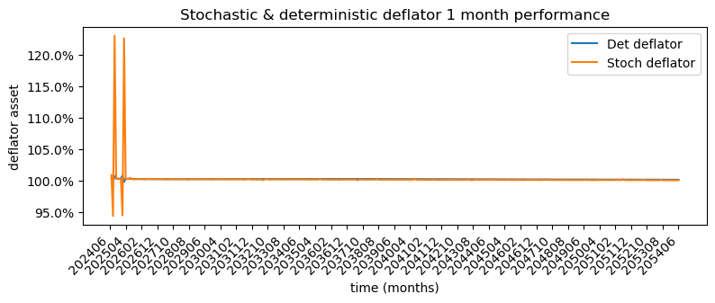

Deterministic and stochastic deflator asset; annual performance

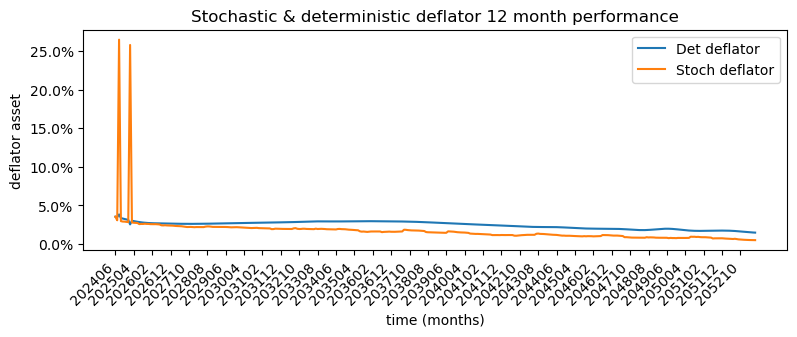

## Test 0; Input curve is equal to the deterministic

This test verifies if the deterministic deflator equals to the input curve, provided by the company.

The test compares the input curve provided by the company with the equivalent curve calculated from the deterministic deflator.

The original curve provided by the business is an annual yield curve. Therefore, the deterministic deflator is transformed into a corresponding yield curve and compared.

$$ y^A_{DET, DEF} (0, t) = \big[D_{DET, DEF}(0, t)\big]^{-\frac{t}{12}}-1 $$

The test verifies the following relation: $$ y_{INPUT} (0,t) =^? y^A_{DET, DEF} (0, t) $$

Where:

- $t$ is the time of maturity
- $D_{DET, DEF}(0, t)$ is the deterministic deflator at time $t$
- $ y^A_{DET, DEF} (0, t) $ is the yield between time $0$ and $t$ calculated from the deterministic deflator curve
- $y_{INPUT} (0,t)$ is the input yield curve provided by the company to the model provider

Note that the input yield curve is provided on an annual basis while the deflator is a monthly curve. Therefore only every 12-th value of the deflator is compared to the input curve.

The two test statistics used are:

$$ S^0_{AVERAGE} = \frac{1}{T} \sum_{t = 0}^{T} \frac{1}{N} \sum_{i = 0}^N \bigg| y^A_{DET, DEF} (0, t) - y_{INPUT} (0,t) \bigg| $$

$$ S^0_{MAX} = \max_t \bigg|\frac{1}{N} \sum_{i = 0}^N y^A_{DET, DEF} (0, t) - y_{INPUT} (0,t) \bigg| $$

### Test 0; Success criteria

The successful application of the success criteria marks the completion of the test.

|  | TEST_NAME | TEST_MAX | TEST_MEAN |
| --- | --- | --- | --- |
| 0 | COMPARE_INPUT_TO_DET | True | True |

**VISUAL INSPECTION**  
Deterministic and stochastic yield

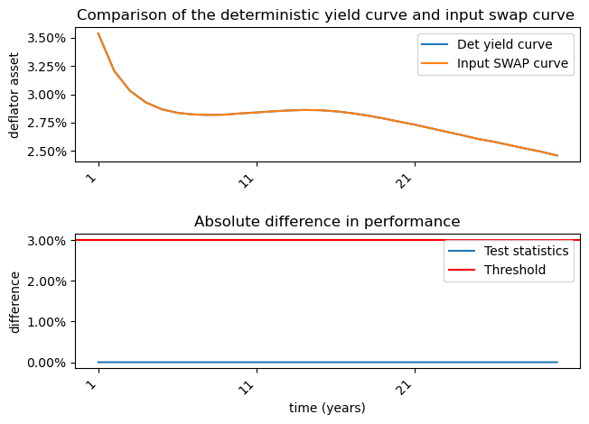

## Test 1; Mean of stochastic deflator is equal to the deterministic

The objective of this test is to compare the average performance of the stochastic deflation asset and the deterministic deflator.

The relationship tested for the spot curves is:

$$ E\bigg[ D_{i, DEF}(0,t) \bigg] =^? D_{DET, DEF} (0,t) $$

The two test statistics used are:

$$ S^1_{AVERAGE} = \frac{1}{T-12} \sum_{t = 0}^{T-12} \frac{1}{N} \sum_{i = 0}^N \bigg| D_{i, DEF}(0,t) - D_{DET, DEF}(0,t) \bigg| $$

$$ S^1_{MAX} = \max_t \bigg|\frac{1}{N} \sum_{i = 0}^N D_{i, DEF}(0,t) - D_{DET, DEF}(0,t) \bigg| $$

Where:

- $N\dots$ is the number scenarios
- $T\dots$ is the number of time increments
- $D_{i, DEF}(0,t) \dots$ is the deflator asset between time `0` and `t`, priced using the stochastic scenario `i`
- $D_{DET, DEF}(0,t)\dots$ is the deflator asset between time `0` and `t` priced using the deterministic scenario
- $S^1_{AVERAGE}\dots$ is the average test statistics for the first test
- $S^1_{MAX}\dots$ is the maximum deviation test statistics for the first test

## Test 1; Success criteria

The successful application of the success criteria marks the completion of the test.

|  | TEST_NAME | TEST_MAX | TEST_MEAN |
| --- | --- | --- | --- |
| 0 | COMPARE_MEAN_TO_DET | False | False |

**VISUAL INSPECTION**  
Deflator asset test

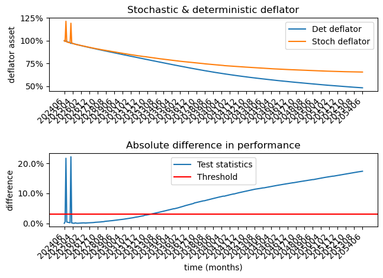

## Test 2: Discounted stochastic performance of spot rate with term of K years

The purpose of this test is to verify if a simple trading strategy using the spot rates of varying terms are arbitrage free excluding the real-world spread.

The test is performed by simulating a buy-and-hold strategy and calculating the return of such a strategy. If the return of such a strategy is equal to the return of the deflator asset, the discounted process is a Martingale.

The Buy-and-hold strategy consists of investing all funds into ZCBs of a selected maturity, holding them until maturity and rolling all proceeds to buy another round of ZCB with the same selected maturity.

The strategy consists of investing for ex. `1` unit of currency in month `k` and withdrawing the accrued payoff at time `T`.

`k` is one of the first $K*12$ months where $K$ is the term of the spot rate curve used.

This payoff can be replicated by investing the initial amount into the deflator asset at time `k` and withdrawing everything at the end time `T`.

If the strategy has a term of `K`-years, $K*12$ separate starting points need to be tested (to cover the entire curve). For each starting point, the performance can be calculated as:

$$ Perf^{BH}_{i,KT,k} (t`)= \prod_{j = 0}^{t`} \left( (1+r_{i,KT}(k+12 K j) \right)^K $$

Where $t` = 1,2,3,...$. Note that $t`$ represents year multiples of the selected term $K$.

Therefore:

$$ DPerf^{BH}_{i,KT,k} (t`)= E^{Q_k}\big[Perf^{BH}_{i,KT,k} (t`)\big] = Perf^{BH}_{i,KT,k} (t`) * D_{i, RF}(0,k+12 K t`) $$

is a Martingale. The test verifies the following asymptotic identity:

$$ DPerf^{BH}_{i,KT,k} (t`) =^? 1 $$

Where:

- $Q$ is the numeraire used in this test which is the terminal value of the deflator asset starting at time `k`

For the second test, the two test statistics used are:

$$ S_{AVERAGE} = \frac{1}{T`} \sum_{t` = 0}^{T`} \frac{1}{N} \big| \sum_{i = 0}^N (DPerf^{BH}_{i,1T,k} (t`) - 1) \big| $$

$$ S_{MAX} = \max_{t`} \bigg| \frac{1}{N} \sum_{i = 0}^N (DPerf^{BH}_{i,1T,k} (t`) - 1) \bigg| $$

Note that the selected spot curve maturities are 1,2,3 and 5.

### Test 2.1; Discounted stochastic performance of spot rate and the spot rate with term of 1-year

This section verifies the performance of a strategy that invests 1 unit at time 0 and reinvests at maturity.

1-year Buy-and-hold strategy test

|  | 0 | 1 | 2 | 3 | 4 | 5 | 6 | 7 | 8 | 9 | ... | 90 | 91 | 92 | 93 | 94 | 95 | 96 | 97 | 98 | 99 |
| --- | --- | --- | --- | --- | --- | --- | --- | --- | --- | --- | --- | --- | --- | --- | --- | --- | --- | --- | --- | --- | --- |
| 0 | 6.055182e-07 | 6.055182e-07 | 6.055182e-07 | 6.055182e-07 | 6.055182e-07 | 6.055182e-07 | 6.055182e-07 | 6.055182e-07 | 6.055182e-07 | 6.055182e-07 | ... | 6.055182e-07 | 6.055182e-07 | 6.055182e-07 | 6.055182e-07 | 6.055182e-07 | 6.055182e-07 | 6.055182e-07 | 6.055182e-07 | 6.055182e-07 | 6.055182e-07 |
| 1 | -3.364843e-03 | -1.113617e-03 | -5.392087e-03 | -2.898091e-03 | -1.148268e-03 | 2.218042e-04 | -3.167815e-04 | 1.685380e-03 | 1.412433e-03 | -4.338661e-03 | ... | -1.721486e-03 | -3.216732e-03 | -2.254059e-03 | -1.457157e-03 | -3.859590e-03 | 9.234869e-04 | -3.984834e-03 | 6.404168e-04 | -4.449268e-03 | -7.904327e-03 |
| 2 | -6.518775e-03 | -7.453503e-01 | -6.231408e-01 | -7.447283e-01 | -7.249080e-01 | -7.819920e-01 | -7.324773e-01 | -5.498065e-01 | -7.307477e-01 | -5.431676e-03 | ... | 1.630530e-03 | -4.028898e-03 | -2.087076e-03 | -1.800731e-03 | -9.245592e-05 | 9.501421e-04 | -3.717819e-03 | 1.473380e-03 | -4.916395e-03 | -6.596075e-03 |
| 3 | -2.851448e-03 | 1.545323e-03 | -4.948338e-03 | -1.375886e-03 | -2.259067e-04 | -1.589652e-03 | 1.484687e-03 | 7.999856e-04 | 3.518495e-03 | -6.055512e-03 | ... | 1.168940e-03 | -3.359729e-03 | 1.264003e-03 | 9.366334e-04 | -2.569587e-04 | 8.656674e-04 | -3.114047e-03 | -6.103941e-04 | -4.985545e-03 | -8.090843e-03 |
| 4 | -1.514577e-04 | 1.601149e-04 | -5.788634e-03 | 3.514382e-03 | -3.220979e-04 | 3.145654e-04 | 3.132813e-03 | 2.552551e-04 | 3.531883e-03 | -3.881788e-03 | ... | 1.379343e-03 | -3.450431e-03 | 3.699078e-04 | -5.425556e-04 | 3.783900e-03 | 3.838883e-03 | -5.255870e-03 | -6.359006e-04 | -2.950786e-03 | -4.358886e-03 |

1-year Buy-and-hold strategy test; charts

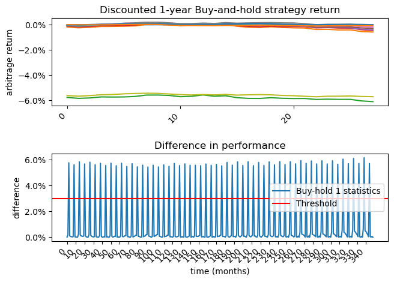

### Test 2.2; Discounted stochastic performance of spot rate and the spot rate with term of 2-years

This section verifies the performance of a strategy that invests 1 unit at time 0 and reinvests at maturity.

2-year Buy-and-hold strategy test; charts

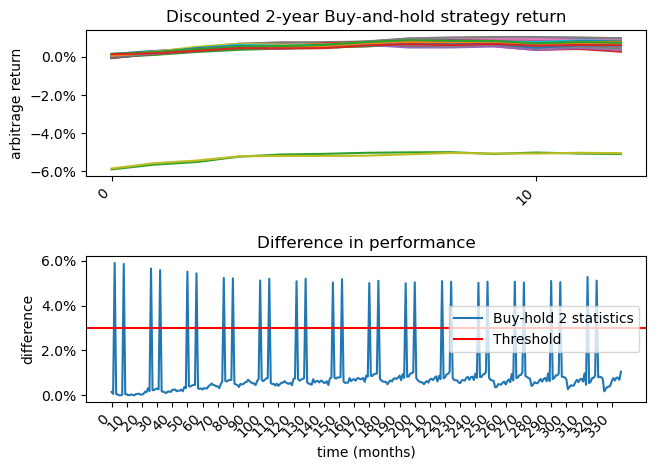

### Test 2.3; Discounted stochastic performance of spot rate and the spot rate with term of 3-years

This section verifies the performance of a strategy that invests 1 unit at time 0 and reinvests at maturity.

3-year Buy-and-hold strategy test; charts

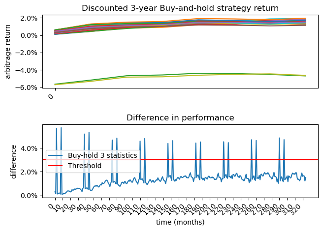

### Test 2.4; Discounted stochastic performance of spot rate and the spot rate with term of 5-years

This section verifies the performance of a strategy that invests 1 unit at time 0 and reinvests at maturity.

5-year Buy-and-hold strategy test; charts

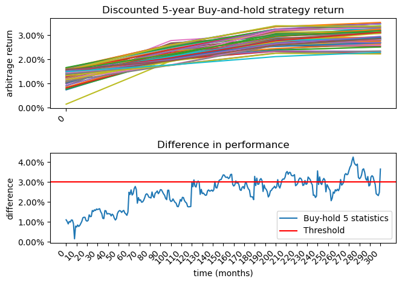

## Test 3; Forward return with a spread of 1-year investment strategy

The purpose of this test is to verify if a simple trading strategy using the forward rates satisfies the no-arbitrage property implied by the model.

The test calculates the return of a forward for each period. If the return of this strategy is equal to the deflator's return, then the discounted process would be a Martingale.

Forward return with a spread of `1`-year strategy consists of buying and selling fixed income assets in a way that the return is equal to a forward rate with constant maturity. In this example, a constant maturity of `1`-year is implemented by buying (long position) a ZCB with a maturity of `K+1`-years and selling (short position) a ZCB with a maturity of `K`-years.

$$ D_{i,KT}(t, t+12K) = \frac{1}{\big(1 + r^A_{i, KT}(t, t+12K) \big)^K} $$$$ Perf^{FR}_{i,KT,(K+1)T}(t, t+12K) =\frac{ D_{i,KT}(t, t+12K)}{ D_{i, (K+1)T}(t, t+12K)} = $$$$ = \frac{\frac{1}{\big(1 + r^A_{i, KT}(t, t+12K) \big)^{K}}}{\frac{1}{\big(1 + r^A_{i, (K+1)T}(t, t+12K) \big)^{K+1}}} = \frac{\left( 1 + r^A_{i, (K+1)T}(t, t+12)\right)^{K+1}}{\left( 1 + r^A_{i, KT}(t, t+12) \right)^{K}} $$

Therefore:

$$ DPerf^{FR}_{i,KT,(K+1)T}(t, t+12K) = \frac{Perf^{FR}_{i,KT,(K+1)T}(t, t+12K)}{\big(1+ r^A_{i,DEF}(t+12K)\big)} $$

is a Martingale.

The test verifies the following asymptotic identity:

$$ E^Q\big[Perf^{FR}_{i,KT,(K+1)T}(t, t+12K)\big] =^? 1 $$

In the third test, the two test statistics used are:

$$ S_{AVERAGE} = \frac{1}{T-12} \sum_{t = 0}^{T-12}\frac{1}{N} \sum_{i = 0}^N \big| DPerf^{FR}_{i,KT,(K+1)T}(t, t+12K) - 1 \big| $$
$$ S_{MAX} = \max_t \bigg|\frac{1}{N} \sum_{i = 0}^N (DPerf^{FR}_{i,KT,(K+1)T}(t, t+12K) - 1) \bigg| $$

Where:

- $Q$ is the numeraire used in this test which is the 1-year forward rate of the deflator
- $ Perf^{FR}_{i,TK,TK+1}(t) $ Annual return of a forward return strategy, issued at time `0`, maturing at time `t` and priced using the spot curves with term `TK` and `TK+1` in scenario `i`
- $ DPerf^{FR}_{i,TK,TK+1}(t) $ Discounted annual return of a forward return strategy, issued at time `0`, maturing at time `t` and priced using the spot curves with term `TK` and `TK+1` in scenario `i`

### Test 3.1; Forward return with a spread of 1-year investment strategy with terms 1 and 2

This section shows plots for forward return strategy using terms 1 and 2.

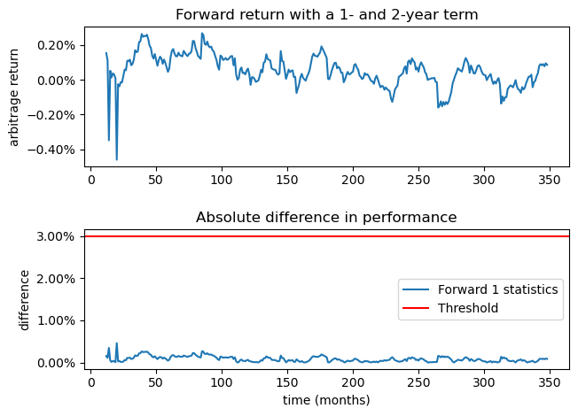

### Test 3.2; Forward return with a spread of 1-year investment strategy with terms 2 and 3

This section shows plots for forward return strategy using terms 2 and 3.

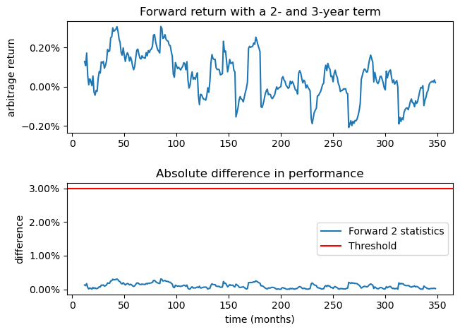

## Test 2 and 3; Success criteria

The successful application of the success criteria marks the completion of the test.

|  | TEST_NAME | Strategy | Maturities | TEST_MAX | TEST_MEAN |
| --- | --- | --- | --- | --- | --- |
| 0 | MARTINGALE_SPOT | SPOT | TERM 1 | False | True |
| 1 | MARTINGALE_SPOT | SPOT | TERM 2 | False | True |
| 2 | MARTINGALE_SPOT | SPOT | TERM 3 | False | True |
| 3 | MARTINGALE_SPOT | SPOT | TERM 5 | False | True |
| 4 | MARTINGALE_INDEX | FORWARD | 1_AND_2 | True | True |
| 5 | MARTINGALE_INDEX | FORWARD | 2_AND_3 | True | True |

## Test 4: Manual calculation of swaptions is equal to market swaptions

Many classes of models can be calibrated using the swaption volatilities. The purpose of this test is to verify if the empirically calculated swaption implied volatilities are similar to the implied volatilities used in the calibration of the model.

This check calculates the swaption value from the output of the scenario generator. The value of the calculated swaptions should be close to the ones obtained in the market and used in the calibration routine.

The test is performed by calculating the swap rate of the deterministic and stochastic scenarios. This information is then used to calculate the swaption prices using the deterministic swap rate as the strike price. Then a root finding algorithm is used to calculate the implied volatilities assuming a Bachelier model.

To calculate the swaption implied volatilities at each tenor and maturity, the following steps are preformed:

1. Calculate the swap rate at-the-money of the input risk-free curve
2. Calculate the annual factors of the at-the-money swap curve
3. Calculate the relevant swap rate of each scenario
4. Calculate the swaption value using the risk-free at-the-money swap rate as the strike price
5. Calculate the average swaption price across scenarios
6. Calculate the implied volatility of the swaption using the Bachelier model
7. Use Newton-Rapson to find the implied Volatility
8. Compare the calculated implied volatilities with the input

The discount factor given a spot curve can be calculated as:

$$ D_{i,jT}(t) = \frac{1}{\big(1 + r^A_{i,jT}(t)\big)^{j}} $$

#### Step 1: Calculate the swap rate at-the-money of the input risk-free curve

$$ SWATM_{DET, RF, M T}(0,t) = \frac{D_{DET, DEF}(0,t) - D_{DET, DEF}(0,t+M))}{\sum_{j = t}^{t+M} D_{DET, DEF}(0,j)} $$

or in Brigo&Mercurio p.18

$$ K_{ATM} = S_{\alpha,\beta}(0) = \frac{P(0,T_{\alpha}) - P(0,T_{\beta})}{\sum_{i =\alpha+1}^{\beta}\tau_i P(0, T_i)} $$

#### Step 2: Calculate the annual factors of the at-the-money swap curve

$$ SWANF_{DET, DEF, M T}(0, t) = \sum_{j = t}^{t+M} D_{DET, DEF, jT}(0,t) $$

or Brigo&Mercurio p.240

$$ C_{\alpha, \beta}(t) = \sum_{i = \alpha+1}^{\beta} \tau_i P(t, T_i) $$

#### Step 3: Calculate the relevant swap rate of each scenario

$$ SWAP_{i, M T}(0, t ) = \frac{1 - D_{i, M T}(0,t)}{\sum_{j = 1}^{M} D_{i, j T}(0, t)} $$

or Brigo&Mercurio p.239 eq(6.33) $$ S_{\alpha, \beta}(t) = \frac{1-\prod_{j =\alpha+1}^{\beta}\frac{1}{1+\tau_j f_j(t)}}{\sum_{i =\alpha+1}^{\beta}\tau_i \prod_{j=\alpha+1}^{i}\frac{1}{1+\tau_jF_j(t)}} $$

#### Step 4: Calculate the swaption value using the risk-free at-the-money swap rate as the strike price

$$ SWAPTION_{i, M T}(0, t) = D_i(0, t) \max{\big[0, SWAP_{i, M T} (0,t) - SWATM_{DET, RF, M T}(0,t)\big]} \sum_{j = 1}^{M} D_{DET, DEF, j T}(0, t) $$

or Brigo&Mercurio p.240 eq(6.36)

$$ D(0, T_{\alpha}) (S_{\alpha, \beta}(T_{\alpha})-K)^{+} \sum_{i=\alpha+1}^{\beta} \tau_i P(T_{\alpha}, T_i) $$

#### Step 5: Calculate the average swaption price across scenarios

$$ SWAPTION_{M T}(0,t) = \frac{1}{N}\sum_{j = 1}^{N} SWAPTION_{j, M T}(0, t) $$

#### Step 6: Calculate the implied volatility of the payer swaption using the Bachelier model

The Bachelier model is used to calculate price of a receiver swaption. The Bachelier model is used with the swap price equal to the strike price. In the next step, the empirical volatility is calibrated so that the price of this swaption is equal to the price calculated using the stochastic scenarios.

$$ d = \frac{Sw-K}{v * \sqrt{T}} $$$$ nd1 = N(d) $$

Payer: $$ price = A \bigg[ (Sw-K) * nd1 + \frac{v*\sqrt{T}}{\sqrt{2\pi}} e^{-\frac{d^2}{2}}\bigg] $$

Where:

- $Sw\dots$ forward swap rate
- $K\dots$ Strike rate of the swaption
- $v\dots$ Volatility
- $T\dots$ Maturity
- $A\dots$ Annuity factor

#### Step 7: Use Newton-Rapson to find the implied Volatility

To calculate the implied volatility of a swaption, we use the fact that the volatility will result in the swaption being in-the-money. A search algorithm is used to find this volatility.

In each step,

1. Calculate the value of swaption using the current implied volatility guess
2. Calculate the derivative of the payer swaption w.r.t. the volatility
3. Use the derivative in the Newton method to adjust implied volatility
4. If the derivative is flat or algorithm has reached maximum number of iterations, exit

From an initial guess, the algorithm used is:

$$ d = \frac{Sw- K}{v \sqrt{T}} $$$$ dv = \frac{\partial d}{\partial vol}= A \frac{e^{-\frac{d^2}{2}}}{\sqrt{2\pi}}\bigg[ \frac{-(Sw-K) d}{v}+\sqrt{T} + \sqrt{T} d^2\bigg] $$$$ vol = vol-\frac{Func}{dv} $$

Until:

- $|\frac{Func}{dx}| < \epsilon$
- $i=MaxIter$

Where:

Func = bachelier_swap(Payer, Sw, K, v T, A, Option Value, Initial Guess)

Where:

- $Sw\dots$ forward swap rate
- $K\dots$ Strike
- $v\dots$ Volatility
- $T\dots$ Maturity
- $A\dots$ Annuity factor
- $OptionValue\dots$ value of the option
- $guess\dots$ initial guess of the implied volatility

## Test 4; Success criteria

The successful application of the success criteria marks the completion of the test. For this test, the result is an implied volatility matrix. The tester should compare this result with the matrix showed in the testing report.

|  | TEST_NAME | TEST_MAX | TEST_MEAN |
| --- | --- | --- | --- |
| 0 | CALC_SWAPTION | False | False |

**VISUAL INSPECTION**  
Implied volatility comparison; Implied volatilities provided by the vendor

| Tenor | 1 | 2 | 3 | 4 | 5 | 7 | 10 | 15 |
| --- | --- | --- | --- | --- | --- | --- | --- | --- |
| 1.0 | 0.007961 | 0.008291 | 0.008731 | 0.008754 | 0.008730 | 0.008720 | 0.00865 | 0.008390 |
| 2.0 | 0.008259 | 0.008459 | 0.008747 | 0.008828 | 0.008819 | 0.008730 | 0.00861 | 0.008307 |
| 5.0 | 0.008890 | 0.008890 | 0.008760 | 0.008580 | 0.008520 | 0.008392 | 0.00824 | 0.007850 |
| 10.0 | 0.008320 | 0.008300 | 0.008126 | 0.007950 | 0.007800 | 0.007610 | 0.00737 | 0.006930 |
| 15.0 | 0.007611 | 0.007686 | 0.007560 | 0.007360 | 0.007190 | 0.006930 | 0.00667 | 0.006220 |

Implied volatility comparison; implied volatilities calculated by the script

|  | 1 | 2 | 3 | 4 | 5 | 7 | 10 | 15 |
| --- | --- | --- | --- | --- | --- | --- | --- | --- |
| 1 | 0.005446 | 0.005066 | 0.004938 | 0.004813 | 0.004811 | 0.004850 | 0.005132 | 0.005366 |
| 2 | 0.005127 | 0.005082 | 0.005072 | 0.005082 | 0.005101 | 0.005143 | 0.005176 | 0.004970 |
| 5 | 0.004166 | 0.004259 | 0.004175 | 0.004236 | 0.004295 | 0.004277 | 0.004375 | 0.004437 |
| 10 | 0.002593 | 0.002623 | 0.002433 | 0.002308 | 0.002255 | 0.002206 | 0.002003 | 0.001711 |
| 15 | 0.001599 | 0.001806 | 0.001646 | 0.001504 | 0.001482 | 0.001512 | 0.001399 | 0.001166 |

Implied volatility comparison; difference between assumed and calculated (calculated/assumed -1)

|  | 1 | 2 | 3 | 4 | 5 | 7 | 10 | 15 |
| --- | --- | --- | --- | --- | --- | --- | --- | --- |
| 1 | -31.589115 | -38.899724 | -43.440306 | -45.023338 | -44.891680 | -44.376685 | -40.666277 | -36.046286 |
| 2 | -37.925100 | -39.923102 | -42.016173 | -42.430817 | -42.162174 | -41.092350 | -39.882588 | -40.171525 |
| 5 | -53.133627 | -52.089594 | -52.337634 | -50.625449 | -49.591766 | -49.034114 | -46.908107 | -43.482864 |
| 10 | -68.828293 | -68.399041 | -70.054932 | -70.970854 | -71.094016 | -71.009441 | -72.820456 | -75.308947 |
| 15 | -78.993572 | -76.504008 | -78.223023 | -79.568417 | -79.393659 | -78.186472 | -79.023083 | -81.254597 |

Implied volatility comparison; heatmap

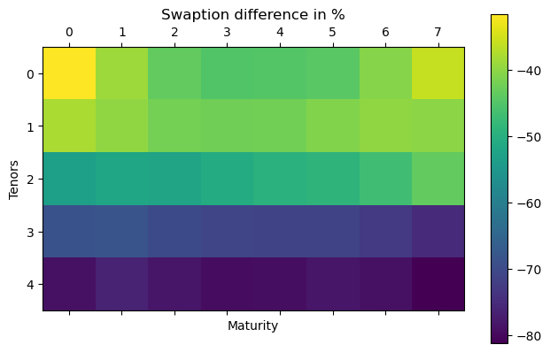

## Test 5: Correlation of GBM indices

The real-world output contains indices generates from a GBM model. This test verifies that the correlation between the total-return indices is the same as the one provided as input.

This test verifies that the empirical correlation is similar to the correlation stated in the report. The test verifies the following indices:

- SX5T (EUR)
- SX5TS (S_EUR)
- LP01TREU (HY)
- LUTLTREH (GOVT)
- SX5T (Infra)
- SX5T (Propt)
- LP01TREU (Loans)
- NDDUUS (USD)
- LUTLTRUU (GOVT USD)

The test is performed by calculating the Pearson correlation for all selected indices at each individual time-point. This gives a number of correlation matrices equal to the number of time-points in the model. The final empirical correlation is calculated as the mean of these matrices element-wise.

## Test 5; Success criteria

The successful application of the success criteria marks the completion of the test.

|  | TEST_NAME | TEST_MAX | TEST_MEAN |
| --- | --- | --- | --- |
| 0 | CORRELATION_INDICES | True | True |

**VISUAL INSPECTION**  
Index correlation; calculated

|  | EUR_EUR_GTH_IDX_0 | EUR_S_EUR_GTH_IDX_0 | EUR_HY_GTH_IDX_0 | EUR_GOVT_GTH_IDX_0 | EUR_INFRA_GTH_IDX_0 | EUR_PROPT_GTH_IDX_0 | EUR_LOANS_GTH_IDX_0 | USD_USD_GTH_IDX_0 | USD_GOVT_USD_GTH_IDX_0 |
| --- | --- | --- | --- | --- | --- | --- | --- | --- | --- |
| EUR_EUR_GTH_IDX_0 | 1.000000 | 0.064292 | -0.054599 | -0.183155 | -0.267417 | 0.065490 | 0.066557 | 0.008127 | -0.040822 |
| EUR_S_EUR_GTH_IDX_0 | 0.064292 | 1.000000 | -0.972242 | 0.683040 | -0.093329 | 0.996932 | 0.997415 | 0.010120 | 0.789903 |
| EUR_HY_GTH_IDX_0 | -0.054599 | -0.972242 | 1.000000 | -0.647380 | 0.119133 | -0.972268 | -0.971929 | 0.007821 | -0.766637 |
| EUR_GOVT_GTH_IDX_0 | -0.183155 | 0.683040 | -0.647380 | 1.000000 | 0.079387 | 0.682717 | 0.683870 | 0.013688 | 0.710074 |
| EUR_INFRA_GTH_IDX_0 | -0.267417 | -0.093329 | 0.119133 | 0.079387 | 1.000000 | -0.094904 | -0.093089 | 0.021341 | 0.031339 |
| EUR_PROPT_GTH_IDX_0 | 0.065490 | 0.996932 | -0.972268 | 0.682717 | -0.094904 | 1.000000 | 0.998082 | 0.009888 | 0.790241 |
| EUR_LOANS_GTH_IDX_0 | 0.066557 | 0.997415 | -0.971929 | 0.683870 | -0.093089 | 0.998082 | 1.000000 | 0.010781 | 0.790521 |
| USD_USD_GTH_IDX_0 | 0.008127 | 0.010120 | 0.007821 | 0.013688 | 0.021341 | 0.009888 | 0.010781 | 1.000000 | 0.011750 |
| USD_GOVT_USD_GTH_IDX_0 | -0.040822 | 0.789903 | -0.766637 | 0.710074 | 0.031339 | 0.790241 | 0.790521 | 0.011750 | 1.000000 |

Index correlation; assumed

|  | EUR_EUR_GTH_IDX_0 | EUR_S_EUR_GTH_IDX_0 | EUR_HY_GTH_IDX_0 | EUR_GOVT_GTH_IDX_0 | EUR_INFRA_GTH_IDX_0 | EUR_PROPT_GTH_IDX_0 | EUR_LOANS_GTH_IDX_0 | USD_USD_GTH_IDX_0 | USD_GOVT_USD_GTH_IDX_0 |
| --- | --- | --- | --- | --- | --- | --- | --- | --- | --- |
| EUR_EUR_GTH_IDX_0 | 1.000000 | 0.051297 | -0.059954 | -0.192340 | -0.279997 | 0.051278 | 0.051939 | -0.001662 | -0.055077 |
| EUR_S_EUR_GTH_IDX_0 | 0.051297 | 1.000000 | -0.984446 | 0.682680 | -0.091776 | 0.998956 | 0.994809 | 0.003283 | 0.789074 |
| EUR_HY_GTH_IDX_0 | -0.059954 | -0.984446 | 1.000000 | -0.666828 | 0.101050 | -0.984492 | -0.992920 | -0.004721 | -0.776468 |
| EUR_GOVT_GTH_IDX_0 | -0.192340 | 0.682680 | -0.666828 | 1.000000 | 0.074234 | 0.682664 | 0.683419 | 0.001550 | 0.706225 |
| EUR_INFRA_GTH_IDX_0 | -0.279997 | -0.091776 | 0.101050 | 0.074234 | 1.000000 | -0.091337 | -0.092757 | -0.002572 | 0.023532 |
| EUR_PROPT_GTH_IDX_0 | 0.051278 | 0.998956 | -0.984492 | 0.682664 | -0.091337 | 1.000000 | 0.994845 | 0.002872 | 0.789145 |
| EUR_LOANS_GTH_IDX_0 | 0.051939 | 0.994809 | -0.992920 | 0.683419 | -0.092757 | 0.994845 | 1.000000 | 0.003758 | 0.785725 |
| USD_USD_GTH_IDX_0 | -0.001662 | 0.003283 | -0.004721 | 0.001550 | -0.002572 | 0.002872 | 0.003758 | 1.000000 | 0.009369 |
| USD_GOVT_USD_GTH_IDX_0 | -0.055077 | 0.789074 | -0.776468 | 0.706225 | 0.023532 | 0.789145 | 0.785725 | 0.009369 | 1.000000 |

Index correlation; difference

|  | EUR_EUR_GTH_IDX_0 | EUR_S_EUR_GTH_IDX_0 | EUR_HY_GTH_IDX_0 | EUR_GOVT_GTH_IDX_0 | EUR_INFRA_GTH_IDX_0 | EUR_PROPT_GTH_IDX_0 | EUR_LOANS_GTH_IDX_0 | USD_USD_GTH_IDX_0 | USD_GOVT_USD_GTH_IDX_0 |
| --- | --- | --- | --- | --- | --- | --- | --- | --- | --- |
| EUR_EUR_GTH_IDX_0 | 0.000000 | 0.012995 | 0.005355 | 0.009185 | 0.012580 | 0.014211 | 0.014618 | 0.009788 | 0.014255 |
| EUR_S_EUR_GTH_IDX_0 | 0.012995 | 0.000000 | 0.012204 | 0.000359 | -0.001553 | -0.002025 | 0.002606 | 0.006837 | 0.000829 |
| EUR_HY_GTH_IDX_0 | 0.005355 | 0.012204 | 0.000000 | 0.019447 | 0.018083 | 0.012224 | 0.020991 | 0.012542 | 0.009832 |
| EUR_GOVT_GTH_IDX_0 | 0.009185 | 0.000359 | 0.019447 | 0.000000 | 0.005153 | 0.000053 | 0.000451 | 0.012138 | 0.003849 |
| EUR_INFRA_GTH_IDX_0 | 0.012580 | -0.001553 | 0.018083 | 0.005153 | 0.000000 | -0.003567 | -0.000332 | 0.023912 | 0.007807 |
| EUR_PROPT_GTH_IDX_0 | 0.014211 | -0.002025 | 0.012224 | 0.000053 | -0.003567 | 0.000000 | 0.003237 | 0.007016 | 0.001095 |
| EUR_LOANS_GTH_IDX_0 | 0.014618 | 0.002606 | 0.020991 | 0.000451 | -0.000332 | 0.003237 | 0.000000 | 0.007023 | 0.004796 |
| USD_USD_GTH_IDX_0 | 0.009788 | 0.006837 | 0.012542 | 0.012138 | 0.023912 | 0.007016 | 0.007023 | 0.000000 | 0.002381 |
| USD_GOVT_USD_GTH_IDX_0 | 0.014255 | 0.000829 | 0.009832 | 0.003849 | 0.007807 | 0.001095 | 0.004796 | 0.002381 | 0.000000 |

## Test 6: Maximum likelihood estimation for GBM

The purpose of this test is to verify if the parameters used in the generation of the GBM indices are the same as the ones provided as input.

For each total-return index, a maximum likelihood (ML) parameter estimation is performed. The estimated parameters are then compared to the ones provided as input.

The ML test performs a ML estimation on each scenario. The final estimated parameter is the mean of the estimations. The same procedure is performed for both the mean and the variance parameter.

For an iid sequence of Geometric Brownian motion increments,

$$ f(x_i │ \mu, \sigma^2) = \frac{1}{\sigma \sqrt{2 \pi}} e^{- \frac{(x_i - \mu)^2}{2 \sigma^2}} $$$$ L(\mu, \sigma) = \prod_{i=1}^N f(x_i │ \mu, \sigma^2) =\prod_{i=1}^N \frac{1}{\sigma \sqrt{2 \pi}} e^{- \frac{(x_i - \mu)^2}{2 \sigma^2}} = $$$$ = (\sigma^2)^{-\frac{N}{2}} (2\pi)^{- \frac{N}{2}} e^{-\sum_{i=1}^N \frac{(x_i - \mu)^2}{2 \sigma^2}} = (\sigma^2)^{-\frac{N}{2}} (2\pi)^{- \frac{N}{2}} e^{-\frac{1}{2 \sigma^2}\sum_{i=1}^N (x_i - \mu)^2} $$

The log-likelihood is:

$$ l(\mu, \sigma) = ln(L(\mu, \sigma)) = - \frac{N}{2} ln(\sigma^2) -\frac{N}{2} ln(2 \pi) - \frac{1}{2 \sigma^2} \sum_{i=1}^N (x_i - \mu)^2 = $$$$ = - \frac{N}{2} ln(\sigma^2) - \frac{N}{2} ln(2 \pi) - \frac{1}{2 \sigma^2} \sum_{i=1}^N (x_i - \mu)^2 $$

The derivation for $\mu$:

$$ \frac{\partial l(\mu, \sigma)}{\partial \mu} = \frac{1}{\sigma^2} \sum_{i=1}^N (x_i - \mu) = \frac{1}{\sigma^2}\big[\sum_{i=1}^N x_i - N \mu \big] $$

Second derivative for $\mu$: $$ \frac{\partial^2 l(\mu, \sigma)}{\partial^2 \mu} = -\frac{N}{\sigma^2} $$

The peak is where the derivative is equal to 0 $$ \frac{\partial l(\mu, \sigma)}{\partial \mu} │_{(\mu, \sigma) = (\hat{\mu}, \hat{\sigma})} = 0 $$

$$ \frac{1}{\sigma^2}\bigg[ \sum_{i=1}^N x_i - N \hat{\mu} \bigg] = 0 $$$$ \hat{\mu} = \frac{1}{N} \sum_{i=1}^N x_i $$

The derivation for $\sigma$:

$$ \frac{\partial l(\mu, \sigma)}{\partial \sigma^2} = - \frac{N}{2}\frac{1}{\sigma^2} + \frac{1}{2 (\sigma^2)^2} \sum_{i=1}^N (x_i - \mu)^2 $$

The second derivative for $\sigma$ $$ \frac{\partial^2 l(\mu, \sigma)}{\partial^2 \sigma^2} = \frac{N}{2} \frac{1}{(\sigma^2)^2} - \frac{1}{(\sigma^2)^3}\sum_{i=1}^N (x_i - \mu)^2 $$

The peak is where the derivative is equal to 0: $$ \frac{\partial l(\mu, \sigma)}{\partial \sigma} │_{(\mu, \sigma) = (\hat{\mu}, \hat{\sigma})} = 0 $$

$$ 0 = - \frac{N}{2} \frac{1}{\hat{\sigma}^2} + \frac{1}{(\hat{\sigma}^2)^2} \sum_{i=1}^N (x_i - \hat{\mu})^2 $$$$ \frac{N}{2} \frac{1}{\hat{\sigma}^2} = \frac{1}{(\hat{\sigma}^2)^2} \sum_{i=1}^N (x_i - \hat{\mu})^2 $$$$ \hat{\sigma}^2 = \frac{1}{N} \sum_{i=1}^N (x_i - \hat{\mu})^2 $$

## Test 6; Success criteria

The successful application of the success criteria marks the completion of the test.

```
[False, False]
```

```
[False, False]
```

**VISUAL INSPECTION**  
Maximum likelihood; estimated parameters

|  | TEST_NAME | Estimate mu | Estimate sigma | Mu deterministic | Mu input |
| --- | --- | --- | --- | --- | --- |
| EUR | ML_OF_GBM | 0.099165 | 0.251716 | 0.0450 | 0.0454 |
| S EUR | ML_OF_GBM | 0.022422 | 0.265175 | -0.0450 | -0.0444 |
| High yield | ML_OF_GBM | 0.054107 | 0.131507 | -0.0063 | -0.0072 |
| Government | ML_OF_GBM | 0.064627 | 0.240129 | 0.0065 | 0.0080 |
| Infrastructure | ML_OF_GBM | 0.040643 | 0.250297 | -0.0060 | -0.0066 |
| Property | ML_OF_GBM | 0.083843 | 0.264803 | 0.0165 | 0.0170 |
| Loans | ML_OF_GBM | 0.027885 | 0.131512 | -0.0331 | -0.0330 |
| USD | ML_OF_GBM | 0.124543 | 0.341718 | 0.0450 | 0.0450 |
| GOVT_USD | ML_OF_GBM | 0.111553 | 0.320979 | 0.0450 | 0.0100 |

Maximum likelihood; deterministic mean vs stochastic mean

|  | Mu stoch vs det difference in % |
| --- | --- |
| EUR | 5.416505 |
| S EUR | 6.742199 |
| High yield | 6.040691 |
| Government | 5.812723 |
| Infrastructure | 4.664350 |
| Property | 6.734349 |
| Loans | 6.098538 |
| USD | 7.954328 |
| GOVT_USD | 6.655296 |

Maximum likelihood; input mean vs stochastic mean

|  | Mu stoch vs input difference in % |
| --- | --- |
| EUR | 5.376505 |
| S EUR | 6.682199 |
| High yield | 6.130691 |
| Government | 5.662723 |
| Infrastructure | 4.724350 |
| Property | 6.684349 |
| Loans | 6.088538 |
| USD | 7.954328 |
| GOVT_USD | 10.155296 |

Maximum likelihood; deterministic mean vs stochastic mean chart

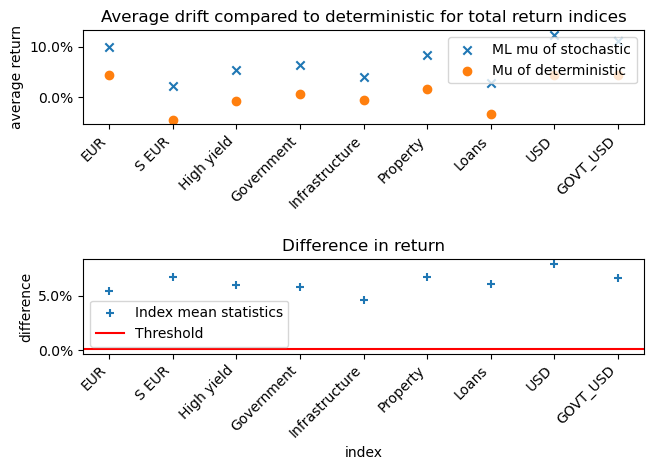

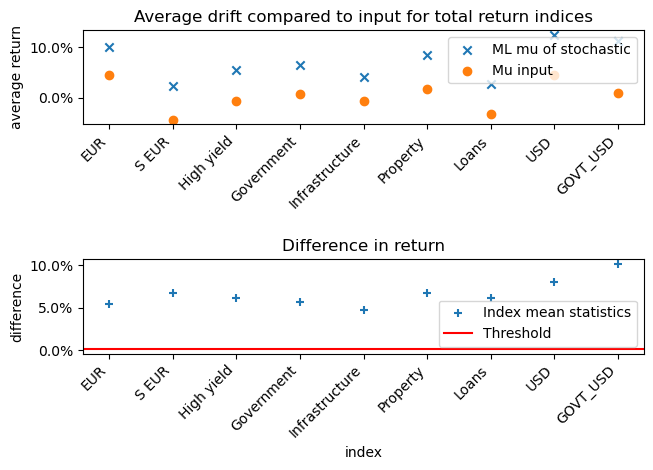

## Conclusion

This section summarizes the inputs and results used in this run. This script conducted tests on the output of the stochastic scenario output. This section shows which tests (if any) failed and which passed. This is shown in the table directly below, followed by a visual representation of results for each test.

### Executive summary

|  | TEST_NAME | TEST_MAX | TEST_MEAN |
| --- | --- | --- | --- |
| 0 | COMPARE_INPUT_TO_DET | True | True |
| 1 | COMPARE_MEAN_TO_DET | False | False |
| 2 | MARTINGALE_SPOT | False | True |
| 3 | MARTINGALE_SPOT | False | True |
| 4 | MARTINGALE_SPOT | False | True |
| 5 | MARTINGALE_SPOT | False | True |
| 6 | MARTINGALE_INDEX | True | True |
| 7 | MARTINGALE_INDEX | True | True |
| 8 | CALC_SWAPTION | False | False |
| 9 | CORRELATION_INDICES | True | True |
| 10 | ML_OF_GBM | False | False |

### The parameters selected are:

- Currency selected is: "EUR"
- Country selected is: "SPA"
- Time fraction set at: 1/12
- List of swaption tenors: [1, 2, 5, 10, 15]
- List of swaption maturities: [1, 2, 3, 4, 5, 7, 10, 15]
- Maximum allowed iterations of Newton-Raphson: 10000
- Accepted tolerance of Newton-Raphson= 0.00001

### Test 0 verifies if the deflator curve equals to the input curve provided by the business

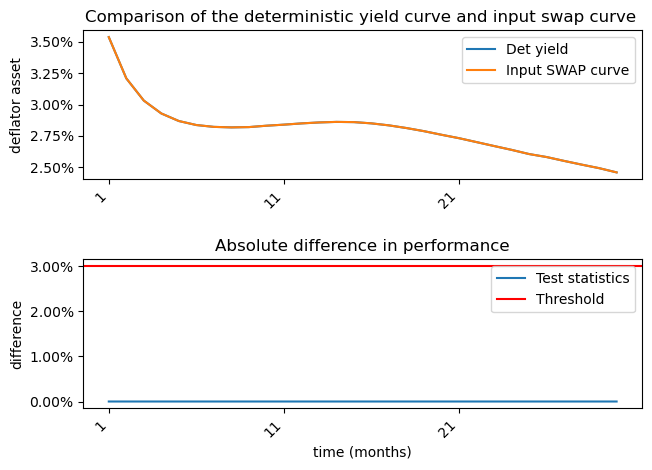

The summary of results for both is in the table bellow

```
[True, True]
```

### Test 1 compares the average performance of the stochastic deflator asset compared with the deterministic deflator asset

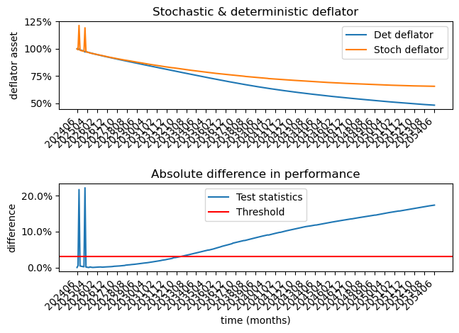

### Tests 2.1, 2.2, 2.3, and 2.4 perform a Martingale test on the first financial strategy using spot rate curves

This Buy-and-hold strategy consists of investing all funds into ZCBs of a selected maturity, holding them until maturity and rolling all proceeds to buy another round of ZCB with the same selected maturity.

Test 2.1 performs the buy-and-hold using the term of `1`-year

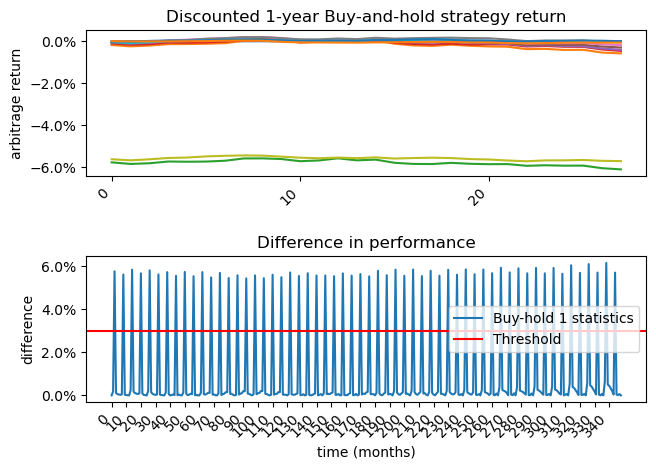

Test 2.2 performs the buy-and-hold using the term of `2`-years

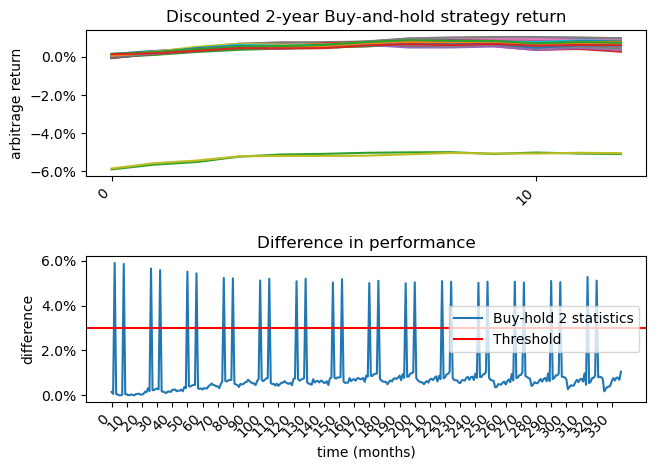

Test 2.3 performs the buy-and-hold using the term of `3`-years

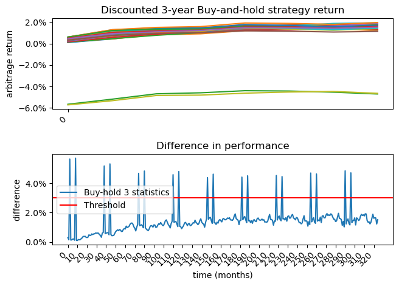

Test 2.4 performs the buy-and-hold using the term of `5`-years

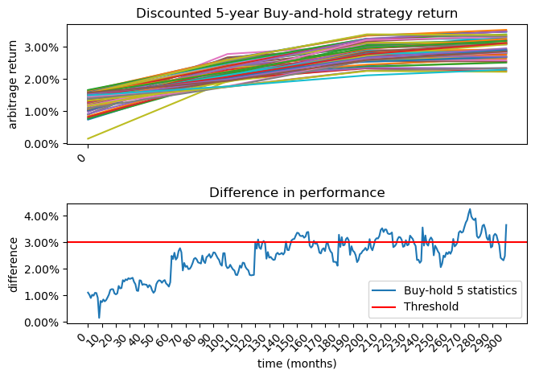

### Test 3 performs a Martingale test on a specific investment strategy using spot curves

The Forward return with a spread of `1`-year strategy using `1`- and `2`-year spot rates consists of buying and selling ZCB bonds with `1`- and `2`-year term. In this example, this consists of buying (long position) a ZCB with a maturity of `2`-years and selling (short position) a ZCB with a maturity of `1`-year.

Test 3.1 performs the strategy with terms 1 and 2

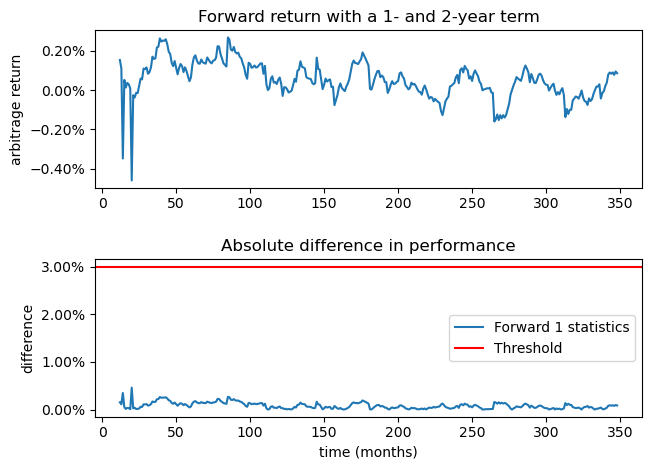

Test 3.2 performs the strategy with terms 2 and 3

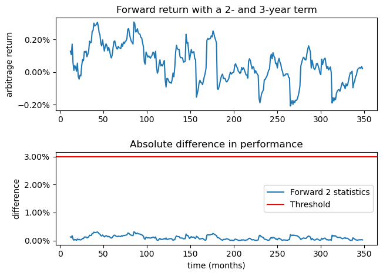

Tests 2 and 3 both plot the performance of different strategies. The summary of results for both is in the table bellow

|  | TEST_NAME | Strategy | Maturities | TEST_MAX | TEST_MEAN |
| --- | --- | --- | --- | --- | --- |
| 0 | MARTINGALE_SPOT | SPOT | TERM 1 | False | True |
| 1 | MARTINGALE_SPOT | SPOT | TERM 2 | False | True |
| 2 | MARTINGALE_SPOT | SPOT | TERM 3 | False | True |
| 3 | MARTINGALE_SPOT | SPOT | TERM 5 | False | True |
| 4 | MARTINGALE_INDEX | FORWARD | 1_AND_2 | True | True |
| 5 | MARTINGALE_INDEX | FORWARD | 2_AND_3 | True | True |

### Test 4 calculates the observed value of swaptions for different maturities and tenors and compares them to the assumed swaption table

```
[False, False]
```

Volatility stated in the report

| Tenor | 1 | 2 | 3 | 4 | 5 | 7 | 10 | 15 |
| --- | --- | --- | --- | --- | --- | --- | --- | --- |
| 1.0 | 0.007961 | 0.008291 | 0.008731 | 0.008754 | 0.008730 | 0.008720 | 0.00865 | 0.008390 |
| 2.0 | 0.008259 | 0.008459 | 0.008747 | 0.008828 | 0.008819 | 0.008730 | 0.00861 | 0.008307 |
| 5.0 | 0.008890 | 0.008890 | 0.008760 | 0.008580 | 0.008520 | 0.008392 | 0.00824 | 0.007850 |
| 10.0 | 0.008320 | 0.008300 | 0.008126 | 0.007950 | 0.007800 | 0.007610 | 0.00737 | 0.006930 |
| 15.0 | 0.007611 | 0.007686 | 0.007560 | 0.007360 | 0.007190 | 0.006930 | 0.00667 | 0.006220 |

Calculated volatility

|  | 1 | 2 | 3 | 4 | 5 | 7 | 10 | 15 |
| --- | --- | --- | --- | --- | --- | --- | --- | --- |
| 1 | 0.005446 | 0.005066 | 0.004938 | 0.004813 | 0.004811 | 0.004850 | 0.005132 | 0.005366 |
| 2 | 0.005127 | 0.005082 | 0.005072 | 0.005082 | 0.005101 | 0.005143 | 0.005176 | 0.004970 |
| 5 | 0.004166 | 0.004259 | 0.004175 | 0.004236 | 0.004295 | 0.004277 | 0.004375 | 0.004437 |
| 10 | 0.002593 | 0.002623 | 0.002433 | 0.002308 | 0.002255 | 0.002206 | 0.002003 | 0.001711 |
| 15 | 0.001599 | 0.001806 | 0.001646 | 0.001504 | 0.001482 | 0.001512 | 0.001399 | 0.001166 |

Difference in volatility (In %)

|  | 1 | 2 | 3 | 4 | 5 | 7 | 10 | 15 |
| --- | --- | --- | --- | --- | --- | --- | --- | --- |
| 1 | -31.589115 | -38.899724 | -43.440306 | -45.023338 | -44.891680 | -44.376685 | -40.666277 | -36.046286 |
| 2 | -37.925100 | -39.923102 | -42.016173 | -42.430817 | -42.162174 | -41.092350 | -39.882588 | -40.171525 |
| 5 | -53.133627 | -52.089594 | -52.337634 | -50.625449 | -49.591766 | -49.034114 | -46.908107 | -43.482864 |
| 10 | -68.828293 | -68.399041 | -70.054932 | -70.970854 | -71.094016 | -71.009441 | -72.820456 | -75.308947 |
| 15 | -78.993572 | -76.504008 | -78.223023 | -79.568417 | -79.393659 | -78.186472 | -79.023083 | -81.254597 |

The visual representation of the difference:

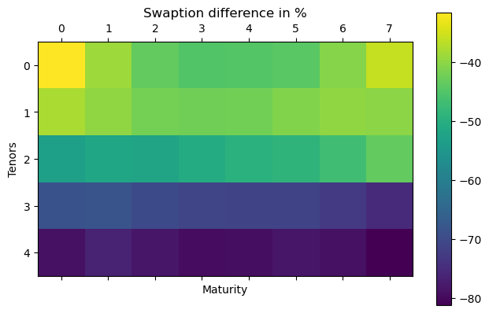

### Test 5 calculates the correlation between total-return indices within a single stochastic scenario file

The correlation is calculated across each period and the mean over all periods is taken as the final correlation number.

```
[True, True]
```

#### Correlation from the validation report

|  | EUR_EUR_GTH_IDX_0 | EUR_S_EUR_GTH_IDX_0 | EUR_HY_GTH_IDX_0 | EUR_GOVT_GTH_IDX_0 | EUR_INFRA_GTH_IDX_0 | EUR_PROPT_GTH_IDX_0 | EUR_LOANS_GTH_IDX_0 | USD_USD_GTH_IDX_0 | USD_GOVT_USD_GTH_IDX_0 |
| --- | --- | --- | --- | --- | --- | --- | --- | --- | --- |
| EUR_EUR_GTH_IDX_0 | 1.000000 | 0.051297 | -0.059954 | -0.192340 | -0.279997 | 0.051278 | 0.051939 | -0.001662 | -0.055077 |
| EUR_S_EUR_GTH_IDX_0 | 0.051297 | 1.000000 | -0.984446 | 0.682680 | -0.091776 | 0.998956 | 0.994809 | 0.003283 | 0.789074 |
| EUR_HY_GTH_IDX_0 | -0.059954 | -0.984446 | 1.000000 | -0.666828 | 0.101050 | -0.984492 | -0.992920 | -0.004721 | -0.776468 |
| EUR_GOVT_GTH_IDX_0 | -0.192340 | 0.682680 | -0.666828 | 1.000000 | 0.074234 | 0.682664 | 0.683419 | 0.001550 | 0.706225 |
| EUR_INFRA_GTH_IDX_0 | -0.279997 | -0.091776 | 0.101050 | 0.074234 | 1.000000 | -0.091337 | -0.092757 | -0.002572 | 0.023532 |
| EUR_PROPT_GTH_IDX_0 | 0.051278 | 0.998956 | -0.984492 | 0.682664 | -0.091337 | 1.000000 | 0.994845 | 0.002872 | 0.789145 |
| EUR_LOANS_GTH_IDX_0 | 0.051939 | 0.994809 | -0.992920 | 0.683419 | -0.092757 | 0.994845 | 1.000000 | 0.003758 | 0.785725 |
| USD_USD_GTH_IDX_0 | -0.001662 | 0.003283 | -0.004721 | 0.001550 | -0.002572 | 0.002872 | 0.003758 | 1.000000 | 0.009369 |
| USD_GOVT_USD_GTH_IDX_0 | -0.055077 | 0.789074 | -0.776468 | 0.706225 | 0.023532 | 0.789145 | 0.785725 | 0.009369 | 1.000000 |

#### Calculated correlation

|  | EUR_EUR_GTH_IDX_0 | EUR_S_EUR_GTH_IDX_0 | EUR_HY_GTH_IDX_0 | EUR_GOVT_GTH_IDX_0 | EUR_INFRA_GTH_IDX_0 | EUR_PROPT_GTH_IDX_0 | EUR_LOANS_GTH_IDX_0 | USD_USD_GTH_IDX_0 | USD_GOVT_USD_GTH_IDX_0 |
| --- | --- | --- | --- | --- | --- | --- | --- | --- | --- |
| EUR_EUR_GTH_IDX_0 | 1.000000 | 0.064292 | -0.054599 | -0.183155 | -0.267417 | 0.065490 | 0.066557 | 0.008127 | -0.040822 |
| EUR_S_EUR_GTH_IDX_0 | 0.064292 | 1.000000 | -0.972242 | 0.683040 | -0.093329 | 0.996932 | 0.997415 | 0.010120 | 0.789903 |
| EUR_HY_GTH_IDX_0 | -0.054599 | -0.972242 | 1.000000 | -0.647380 | 0.119133 | -0.972268 | -0.971929 | 0.007821 | -0.766637 |
| EUR_GOVT_GTH_IDX_0 | -0.183155 | 0.683040 | -0.647380 | 1.000000 | 0.079387 | 0.682717 | 0.683870 | 0.013688 | 0.710074 |
| EUR_INFRA_GTH_IDX_0 | -0.267417 | -0.093329 | 0.119133 | 0.079387 | 1.000000 | -0.094904 | -0.093089 | 0.021341 | 0.031339 |
| EUR_PROPT_GTH_IDX_0 | 0.065490 | 0.996932 | -0.972268 | 0.682717 | -0.094904 | 1.000000 | 0.998082 | 0.009888 | 0.790241 |
| EUR_LOANS_GTH_IDX_0 | 0.066557 | 0.997415 | -0.971929 | 0.683870 | -0.093089 | 0.998082 | 1.000000 | 0.010781 | 0.790521 |
| USD_USD_GTH_IDX_0 | 0.008127 | 0.010120 | 0.007821 | 0.013688 | 0.021341 | 0.009888 | 0.010781 | 1.000000 | 0.011750 |
| USD_GOVT_USD_GTH_IDX_0 | -0.040822 | 0.789903 | -0.766637 | 0.710074 | 0.031339 | 0.790241 | 0.790521 | 0.011750 | 1.000000 |

#### Difference in correlation between validation report and calculated

|  | EUR_EUR_GTH_IDX_0 | EUR_S_EUR_GTH_IDX_0 | EUR_HY_GTH_IDX_0 | EUR_GOVT_GTH_IDX_0 | EUR_INFRA_GTH_IDX_0 | EUR_PROPT_GTH_IDX_0 | EUR_LOANS_GTH_IDX_0 | USD_USD_GTH_IDX_0 | USD_GOVT_USD_GTH_IDX_0 |
| --- | --- | --- | --- | --- | --- | --- | --- | --- | --- |
| EUR_EUR_GTH_IDX_0 | 0.000000 | 0.012995 | 0.005355 | 0.009185 | 0.012580 | 0.014211 | 0.014618 | 0.009788 | 0.014255 |
| EUR_S_EUR_GTH_IDX_0 | 0.012995 | 0.000000 | 0.012204 | 0.000359 | -0.001553 | -0.002025 | 0.002606 | 0.006837 | 0.000829 |
| EUR_HY_GTH_IDX_0 | 0.005355 | 0.012204 | 0.000000 | 0.019447 | 0.018083 | 0.012224 | 0.020991 | 0.012542 | 0.009832 |
| EUR_GOVT_GTH_IDX_0 | 0.009185 | 0.000359 | 0.019447 | 0.000000 | 0.005153 | 0.000053 | 0.000451 | 0.012138 | 0.003849 |
| EUR_INFRA_GTH_IDX_0 | 0.012580 | -0.001553 | 0.018083 | 0.005153 | 0.000000 | -0.003567 | -0.000332 | 0.023912 | 0.007807 |
| EUR_PROPT_GTH_IDX_0 | 0.014211 | -0.002025 | 0.012224 | 0.000053 | -0.003567 | 0.000000 | 0.003237 | 0.007016 | 0.001095 |
| EUR_LOANS_GTH_IDX_0 | 0.014618 | 0.002606 | 0.020991 | 0.000451 | -0.000332 | 0.003237 | 0.000000 | 0.007023 | 0.004796 |
| USD_USD_GTH_IDX_0 | 0.009788 | 0.006837 | 0.012542 | 0.012138 | 0.023912 | 0.007016 | 0.007023 | 0.000000 | 0.002381 |
| USD_GOVT_USD_GTH_IDX_0 | 0.014255 | 0.000829 | 0.009832 | 0.003849 | 0.007807 | 0.001095 | 0.004796 | 0.002381 | 0.000000 |

### Test 6 uses the maximum likelihood estimation to calculate the most likely parameters used in the total-return indices

This test compareds to the calibration documents and the mean of the deterministic index.

Based on the success criteria, a comparison between the deterministic mean and the maximum likelihood estimator test:

```
[False, False]
```

Based on the success criteria, a comparison between the input mean and the maximum likelihood estimator test:

```
[False, False]
```

|  | TEST_NAME | Estimate mu | Estimate sigma | Mu deterministic | Mu input |
| --- | --- | --- | --- | --- | --- |
| EUR | ML_OF_GBM | 0.099165 | 0.251716 | 0.0450 | 0.0454 |
| S EUR | ML_OF_GBM | 0.022422 | 0.265175 | -0.0450 | -0.0444 |
| High yield | ML_OF_GBM | 0.054107 | 0.131507 | -0.0063 | -0.0072 |
| Government | ML_OF_GBM | 0.064627 | 0.240129 | 0.0065 | 0.0080 |
| Infrastructure | ML_OF_GBM | 0.040643 | 0.250297 | -0.0060 | -0.0066 |
| Property | ML_OF_GBM | 0.083843 | 0.264803 | 0.0165 | 0.0170 |
| Loans | ML_OF_GBM | 0.027885 | 0.131512 | -0.0331 | -0.0330 |
| USD | ML_OF_GBM | 0.124543 | 0.341718 | 0.0450 | 0.0450 |
| GOVT_USD | ML_OF_GBM | 0.111553 | 0.320979 | 0.0450 | 0.0100 |

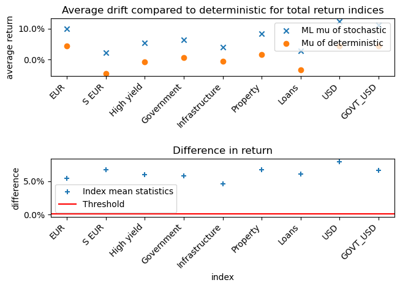

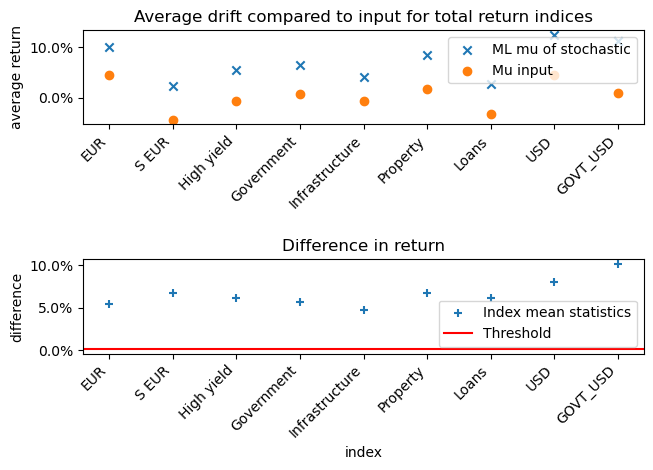

© 2024 Epsinum - All rights reserved.